# Power and PAA results

Jordan Revol, jordan.revol@kuleuven.be, KU Leuven

Yong Zang, yong.zhang@rug.nl, University of Groningen

2024-05-13

# 1 Introduction

This document is the results of the simulation from the manuscript by Zhang et al. (2021) “Meeting the Bare Minimum: Quality Assessment of Idiographic Temporal Networks Using Power Analysis and Predictive Accuracy Analysis”.

# 2 Import

Load libraries

```r
library(dplyr)
library(tidyr)
library(data.table)
library(ggplot2)
library(kableExtra)
library(stringr)
library(graphicalVAR)
library(qgraph)
library(fastmatrix)
```

Import data

```r
df_res <- read.csv("data/df_results.csv")
load("data/list_param.rda")
```

# 3 Plot

Figures of the VAR(1) networks based on the parameters of the different models investigated in the article. The figures can be found in the folder ‘figures/network/’.

## 3.1 Illustration

```r
VAR_phi = list_param$illustration$phi

# Visualize the temporal network
qgraph(t(VAR_phi),
       node.width = 1.6,
       node.height = 1.6,
       mar = c(6, 6, 6, 6),
       # layout = matrix(c(0, 1, 0,
       #                   0, 0, 0,
       #                   2, 0, 3),
       #                 nrow = 3, byrow = T),
       layout = "groups",
       theme = "colorblind",
       negDashed = T,
       edge.labels = T,
    #    labels = c("Relaxed",
    #               "Sad",
    #               "Nervous",
    #               "Concen- \ntration",
    #               "Tired",
    #               "Rumi- \nnation",
    #               "Bodily \ndiscomfort"),
       label.prop = 0.9,
       label.fill.horizontal = .8,
       label.fill.vertical = .8,
       label.scale = TRUE,
       fade = FALSE,
       filetype = "png",
       filename = "figures/network/illustration")
```

```
## Output stored in a:/OneDrive - KU Leuven/WORKSPACE_PHD/2301_Sample_Size_Network_N1/Sample_Size_Network_N1/figures/network/illustration.png
```

## 3.2 Epskamp, van Borkulo, et al., 2018

```r
VAR_phi = list_param$epskamp$phi

# Visualize the temporal network
qgraph(t(VAR_phi),
       node.width = 1.6,
       node.height = 1.6,
       mar = c(6, 6, 6, 6),
       # layout = matrix(c(0, 1, 0,
       #                   0, 0, 0,
       #                   2, 0, 3),
       #                 nrow = 3, byrow = T),
       layout = "groups",
       theme = "colorblind",
       negDashed = T,
       edge.labels = T,
       labels = c("Relaxed",
                  "Sad",
                  "Nervous",
                  "Concen- \ntration",
                  "Tired",
                  "Rumi- \nnation",
                  "Bodily \ndiscomfort"),
       label.prop = 0.9,
       label.fill.horizontal = .8,
       label.fill.vertical = .8,
       label.scale = TRUE,
       fade = FALSE,
       filetype = "png",
       filename = "figures/network/epskamp_vanBorkulo_2018_colorblind")
```

```
## Output stored in a:/OneDrive - KU Leuven/WORKSPACE_PHD/2301_Sample_Size_Network_N1/Sample_Size_Network_N1/figures/network/epskamp_vanBorkulo_2018_colorblind.png
```

## 3.3 Bak2016 Full relaspe

```r
# Network visualization
reg_mat <- list_param$bak2016_full$phi
p_mat <- list_param$bak2016_full$p_mat
plot_reg_mat <- hadamard(reg_mat, 1*(p_mat < .05))

qgraph(t(plot_reg_mat),
       node.width = 1.6,
       node.height = 1.6,
       mar = c(6, 6, 6, 6),
       # layout = matrix(c(0, 1, 0,
       #                   0, 0, 0,
       #                   2, 0, 3),
       #                 nrow = 3, byrow = T),
       layout = "groups",
       theme = "colorblind",
       title = "a) Full relapse",
       negDashed = T,
       edge.labels = T,
       labels = c("Down",
                  "Relaxed",
                  "Paranoia",
                  "Hearing \nvoices",
                  "Loss of \ncontrol"),
       label.prop = 0.9,
       label.fill.horizontal = .8,
       label.fill.vertical = .8,
       label.scale = TRUE,
       fade = FALSE,
       filetype = "png",
       filename = "figures/network/Bak2016_full_relapse_combine")
```

```
## Output stored in a:/OneDrive - KU Leuven/WORKSPACE_PHD/2301_Sample_Size_Network_N1/Sample_Size_Network_N1/figures/network/Bak2016_full_relapse_combine.png
```

```r
# Network visualization
reg_mat <- list_param$bak2016_full_plus1se$phi
p_mat <- list_param$bak2016_full_plus1se$p_mat
plot_reg_mat <- hadamard(reg_mat, 1*(p_mat < .05))

qgraph(t(plot_reg_mat),
       node.width = 1.6,
       node.height = 1.6,
       mar = c(6, 6, 6, 6),
       # layout = matrix(c(0, 1, 0,
       #                   0, 0, 0,
       #                   2, 0, 3),
       #                 nrow = 3, byrow = T),
       layout = "groups",
       theme = "colorblind",
       title = "x) Full relapse estimates +1se",
       negDashed = T,
       edge.labels = T,
       labels = c("Down",
                  "Relaxed",
                  "Paranoia",
                  "Hearing \nvoices",
                  "Loss of \ncontrol"),
       label.prop = 0.9,
       label.fill.horizontal = .8,
       label.fill.vertical = .8,
       label.scale = TRUE,
       fade = FALSE,
       filetype = "png",
       filename = "figures/network/Bak2016_full_relapse_combine_plus1se")
```

```
## Output stored in a:/OneDrive - KU Leuven/WORKSPACE_PHD/2301_Sample_Size_Network_N1/Sample_Size_Network_N1/figures/network/Bak2016_full_relapse_combine_plus1se.png
```

```r
# Network visualization
reg_mat <- list_param$bak2016_full_minus1se$phi
p_mat <- list_param$bak2016_full_minus1se$p_mat
plot_reg_mat <- hadamard(reg_mat, 1*(p_mat < .05))

qgraph(t(plot_reg_mat),
       node.width = 1.6,
       node.height = 1.6,
       mar = c(6, 6, 6, 6),
       # layout = matrix(c(0, 1, 0,
       #                   0, 0, 0,
       #                   2, 0, 3),
       #                 nrow = 3, byrow = T),
       layout = "groups",
       theme = "colorblind",
       title = "x) Full relapse estimates -1se",
       negDashed = T,
       edge.labels = T,
       labels = c("Down",
                  "Relaxed",
                  "Paranoia",
                  "Hearing \nvoices",
                  "Loss of \ncontrol"),
       label.prop = 0.9,
       label.fill.horizontal = .8,
       label.fill.vertical = .8,
       label.scale = TRUE,
       fade = FALSE,
       filetype = "png",
       filename = "figures/network/Bak2016_full_relapse_combine_minus1se")
```

```
## Output stored in a:/OneDrive - KU Leuven/WORKSPACE_PHD/2301_Sample_Size_Network_N1/Sample_Size_Network_N1/figures/network/Bak2016_full_relapse_combine_minus1se.png
```

## 3.4 bak2016_relapse

```r
# Network visualization
reg_mat <- list_param$bak2016_relapse$phi
p_mat <- list_param$bak2016_relapse$p_mat
plot_reg_mat <- hadamard(reg_mat, 1*(p_mat < .05))

qgraph(t(plot_reg_mat),
       node.width = 1.6,
       node.height = 1.6,
       mar = c(6, 6, 6, 6),
       # layout = matrix(c(0, 1, 0,
       #                   0, 0, 0,
       #                   2, 0, 3),
       #                 nrow = 3, byrow = T),
       layout = "groups",
       theme = "colorblind",
       title = "Full relapse",
       negDashed = T,
       edge.labels = T,
       labels = c("Down",
                  "Relaxed",
                  "Paranoia",
                  "Hearing \nvoices",
                  "Loss of \ncontrol"),
       label.prop = 0.9,
       label.fill.horizontal = .8,
       label.fill.vertical = .8,
       label.scale = TRUE,
       fade = FALSE,
       filetype = "png",
       filename = "figures/network/Bak2016_relapse")
```

```
## Output stored in a:/OneDrive - KU Leuven/WORKSPACE_PHD/2301_Sample_Size_Network_N1/Sample_Size_Network_N1/figures/network/Bak2016_relapse.png
```

## 3.5 Bak2016 stable

```r
# Network visualization
reg_mat <- list_param$bak2016_stable$phi
p_mat <- list_param$bak2016_stable$p_mat
plot_reg_mat <- hadamard(reg_mat, 1*(p_mat < .05))

qgraph(t(plot_reg_mat),
       node.width = 1.6,
       node.height = 1.6,
       mar = c(6, 6, 6, 6),
       # layout = matrix(c(0, 1, 0,
       #                   0, 0, 0,
       #                   2, 0, 3),
       #                 nrow = 3, byrow = T),
       title = "a) Point estimates",
       layout = "groups",
       theme = "colorblind",
       negDashed = T,
       edge.labels = T,
       labels = c("Down",
                  "Relaxed",
                  "Paranoia",
                  "Hearing \nvoices",
                  "Loss of \ncontrol"),
       label.prop = 0.9,
       label.fill.horizontal = .8,
       label.fill.vertical = .8,
       label.scale = TRUE,
       fade = FALSE,
       filetype = "png",
       filename = "figures/network/Bak2016_stable")
```

```
## Output stored in a:/OneDrive - KU Leuven/WORKSPACE_PHD/2301_Sample_Size_Network_N1/Sample_Size_Network_N1/figures/network/Bak2016_stable.png
```

```r
# Network visualization
reg_mat <- list_param$bak2016_stable_plus1se$phi
p_mat <- list_param$bak2016_stable_plus1se$p_mat
plot_reg_mat <- hadamard(reg_mat, 1*(p_mat < .05))

qgraph(t(plot_reg_mat),
       node.width = 1.6,
       node.height = 1.6,
       mar = c(6, 6, 6, 6),
       # layout = matrix(c(0, 1, 0,
       #                   0, 0, 0,
       #                   2, 0, 3),
       #                 nrow = 3, byrow = T),
       title = "b) 1 SE larger",
       layout = "groups",
       theme = "colorblind",
       negDashed = T,
       edge.labels = T,
       labels = c("Down",
                  "Relaxed",
                  "Paranoia",
                  "Hearing \nvoices",
                  "Loss of \ncontrol"),
       label.prop = 0.9,
       label.fill.horizontal = .8,
       label.fill.vertical = .8,
       label.scale = TRUE,
       fade = FALSE,
       filetype = "png",
       filename = "figures/network/Bak2016_stable_plus1se")
```

```
## Output stored in a:/OneDrive - KU Leuven/WORKSPACE_PHD/2301_Sample_Size_Network_N1/Sample_Size_Network_N1/figures/network/Bak2016_stable_plus1se.png
```

```r
# Network visualization
reg_mat <- list_param$bak2016_stable_minus1se$phi
p_mat <- list_param$bak2016_stable_minus1se$p_mat
plot_reg_mat <- hadamard(reg_mat, 1*(p_mat < .05))

qgraph(t(plot_reg_mat),
       node.width = 1.6,
       node.height = 1.6,
       mar = c(6, 6, 6, 6),
       # layout = matrix(c(0, 1, 0,
       #                   0, 0, 0,
       #                   2, 0, 3),
       #                 nrow = 3, byrow = T),
       title = "c) 1 SE smaller",
       layout = "groups",
       theme = "colorblind",
       negDashed = T,
       edge.labels = T,
       labels = c("Down",
                  "Relaxed",
                  "Paranoia",
                  "Hearing \nvoices",
                  "Loss of \ncontrol"),
       label.prop = 0.9,
       label.fill.horizontal = .8,
       label.fill.vertical = .8,
       label.scale = TRUE,
       fade = FALSE,
       filetype = "png",
       filename = "figures/network/Bak2016_stable_minus1se")
```

```
## Output stored in a:/OneDrive - KU Leuven/WORKSPACE_PHD/2301_Sample_Size_Network_N1/Sample_Size_Network_N1/figures/network/Bak2016_stable_minus1se.png
```

# 4 All results

Below, you can find the results of the power and PAA analysis for the different models. The tables are organized by model. For each model, you can investigate, across different number of timepoints, the power associated to each parameters and the SPAP score. When there is a parenthesis, the first value corresponds to the performance metric (i.e., power or SPAP) for the -1SE parameter values and the second value corresponds to the +1SE parameter values (e.g., (-1SE, +1SE)) of the models.

```r
pow_table = function(df, name="epskamp"){
    df = df[df$name==name,]

    # Remove columns which contains only 'NA' values
    df <- df[, colSums(is.na(df)) != nrow(df)]
    # Order based on timepoint
    df <- df[order(df$timepoint),]

    # Convert to character
    df[,4:ncol(df)] = lapply(df[,4:ncol(df)], as.character)
    # add star is number higher than .8
    df[,4:ncol(df)] = lapply(df[,4:ncol(df)], function(x) ifelse(as.numeric(x) > .8, paste0(x, "\\*"), x))

    kbl(df, full_width = FALSE, escape = FALSE) %>%
        kable_classic()
}


# Table with merged columns: est (+1SE, -1SE)
pow_table_merge = function(df, name_select="bak2016_full", target="pow", pivot=FALSE){

    df = df %>% filter(grepl(name_select, df$name)) %>%
        mutate(name = str_remove(name, paste0(name_select)),
               name = case_when(name == "_minus1se" ~ "-1SE",
                                name == "_plus1se" ~ "+1SE",
                                TRUE ~ "est"))

    # Remove columns which contains only 'NA' values
    df <- df[, colSums(is.na(df)) != nrow(df)]

    # Round the values
    df[,4:ncol(df)] = round(df[,4:ncol(df)], 3)

    # Convert to character
    df[,4:ncol(df)] = lapply(df[,4:ncol(df)], as.character)
    # add star is number higher than .8
    df[,4:ncol(df)] = lapply(df[,4:ncol(df)], function(x) ifelse(as.numeric(x) > .8, paste0(x, "\\*"), x))

    df = dcast(setDT(df), timepoint ~ name, value.var = names(df)[grepl(target, names(df))], sep="_")

    if (target == "pow"){
        # Merge columns with same prefix (e.g., pow_int_V1_) as est (+1SE, -1SE)
        prefixes = c(unique(str_extract(names(df), "pow_int_V[0-9]+_")),
                    unique(str_extract(names(df), "pow_V[0-9]+_V[0-9]lag_"))
                    )
        prefixes = prefixes[!is.na(prefixes)]
    } else {
        prefixes = unique(str_extract(names(df), "PAP_[0-9].[0-9]*"))
        prefixes = prefixes[!is.na(prefixes)]
        prefixes = paste0(prefixes, "_")
    }

    for (prefix in prefixes) {
        df <- df %>%
            rowwise() %>%
            mutate(!!prefix := paste0(get(paste0(prefix, 'est')), "\n(", get(paste0(prefix, '-1SE')), ", ", get(paste0(prefix, '+1SE')), ")")) %>%
            ungroup()
    }
    df = df %>% select(-contains("est"), -contains("+1SE"), -contains("-1SE"))

    # Order based on timepoint
    # df$timepoint = as.numeric(df$timepoint)
    df <- df[order(df$timepoint),]

    # Pivot table
    if(pivot) df = df %>% gather(variable, value, -timepoint) %>% spread(timepoint, value)

    kbl(df, full_width = FALSE, escape = FALSE) %>%
        kable_classic() %>%
        row_spec(seq(1, nrow(df), 2), background = "lightgray")

}
```

## 4.1 Tables

### 4.1.1 Epskamp

```r
pow_table(df_res, "epskamp")
```

|  | name | vars | timepoint | sim_time | PAP_0.9 | PAP_0.92 | PAP_0.95 | pow_int_V1 | pow_V1_V1lag | pow_V1_V2lag | pow_V1_V3lag | pow_V1_V4lag | pow_V1_V5lag | pow_int_V2 | pow_V2_V1lag | pow_V2_V2lag | pow_V2_V3lag | pow_V2_V4lag | pow_V2_V5lag | pow_int_V3 | pow_V3_V1lag | pow_V3_V2lag | pow_V3_V3lag | pow_V3_V4lag | pow_V3_V5lag | pow_int_V4 | pow_V4_V1lag | pow_V4_V2lag | pow_V4_V3lag | … |
| --- | --- | --- | --- | --- | --- | --- | --- | --- | --- | --- | --- | --- | --- | --- | --- | --- | --- | --- | --- | --- | --- | --- | --- | --- | --- | --- | --- | --- | --- | --- |
| 154 | epskamp | 7 | 25 | 202.83* | 0.078 | 0.0366 | 0.0052 | 0.056 | 0 | 0 | 0 | 0 | 0 | 0.052 | 0 | 0 | 0 | 0 | 0 | 0.0752 | 0 | 0 | 0 | 0 | 0 | 0.066 | 0 | 0 | 0 | … |
| 166 | epskamp | 7 | 47 | 217.03* | 0.4204 | 0.2638 | 0.0678 | 0.0512 | 0 | 0 | 0 | 0 | 0 | 0.0534 | 0 | 0 | 0 | 0 | 0 | 0.1008 | 0 | 0 | 0 | 0 | 0 | 0.0678 | 0 | 0 | 0 | … |
| 155 | epskamp | 7 | 50 | 210.81* | 0.4678 | 0.2968 | 0.0734 | 0.0548 | 0 | 0 | 0 | 0 | 0 | 0.052 | 0 | 0 | 0 | 0 | 0 | 0.113 | 0 | 0 | 0 | 0 | 0 | 0.0828 | 0 | 0 | 0 | … |
| 164 | epskamp | 7 | 63 | 217.28* | 0.6418 | 0.4596 | 0.1442 | 0.0504 | 0 | 0 | 0 | 0 | 0 | 0.0572 | 0 | 0 | 0 | 0 | 0 | 0.1206 | 0 | 0 | 0 | 0 | 0 | 0.0874 | 0 | 0 | 0 | … |
| 156 | epskamp | 7 | 75 | 210.3* | 0.742 | 0.567 | 0.2116 | 0.0528 | 0 | 0 | 0 | 0 | 0 | 0.062 | 0 | 0 | 0 | 0 | 0 | 0.1404 | 0 | 0 | 0 | 0 | 0 | 0.0948 | 0 | 0 | 0 | … |
| 165 | epskamp | 7 | 86 | 213.4* | 0.8112* | 0.657 | 0.2968 | 0.055 | 0 | 0 | 0 | 0 | 0 | 0.0556 | 0 | 0 | 0 | 0 | 0 | 0.1638 | 0 | 0 | 0 | 0 | 0 | 0.105 | 0 | 0 | 0 | … |
| 157 | epskamp | 7 | 100 | 212.46* | 0.8764* | 0.7596 | 0.3932 | 0.0594 | 0 | 0 | 0 | 0 | 0 | 0.057 | 0 | 0 | 0 | 0 | 0 | 0.18 | 0 | 0 | 0 | 0 | 0 | 0.112 | 0 | 0 | 0 | … |
| 158 | epskamp | 7 | 125 | 215.61* | 0.9446* | 0.8612* | 0.5448 | 0.061 | 0 | 0 | 0 | 0 | 0 | 0.0616 | 0 | 0 | 0 | 0 | 0 | 0.2096 | 0 | 0 | 0 | 0 | 0 | 0.1236 | 0 | 0 | 0 | … |
| 159 | epskamp | 7 | 150 | 217.44* | 0.972* | 0.913* | 0.639 | 0.059 | 0 | 0 | 0 | 0 | 0 | 0.0684 | 0 | 0 | 0 | 0 | 0 | 0.2486 | 0 | 0 | 0 | 0 | 0 | 0.1514 | 0 | 0 | 0 | … |
| 160 | epskamp | 7 | 175 | 214.28* | 0.985* | 0.9498* | 0.7158 | 0.0644 | 0 | 0 | 0 | 0 | 0 | 0.0696 | 0 | 0 | 0 | 0 | 0 | 0.282 | 0 | 0 | 0 | 0 | 0 | 0.17 | 0 | 0 | 0 | … |
| 161 | epskamp | 7 | 200 | 214.73* | 0.9906* | 0.9616* | 0.784 | 0.0628 | 0 | 0 | 0 | 0 | 0 | 0.0686 | 0 | 0 | 0 | 0 | 0 | 0.3092 | 0 | 0 | 0 | 0 | 0 | 0.179 | 0 | 0 | 0 | … |
| 162 | epskamp | 7 | 225 | 217.47* | 0.9954* | 0.9836* | 0.8294* | 0.0688 | 0 | 0 | 0 | 0 | 0 | 0.068 | 0 | 0 | 0 | 0 | 0 | 0.3536 | 0 | 0 | 0 | 0 | 0 | 0.1864 | 0 | 0 | 0 | … |
| 163 | epskamp | 7 | 250 | 215.06* | 0.9972* | 0.9848* | 0.8636* | 0.0676 | 0 | 0 | 0 | 0 | 0 | 0.0722 | 0 | 0 | 0 | 0 | 0 | 0.3718 | 0 | 0 | 0 | 0 | 0 | 0.215 | 0 | 0 | 0 | … |
| 167 | epskamp | 7 | 300 | 218.1* | 0.9996* | 0.9944* | 0.9112* | 0.0778 | 0 | 0 | 0 | 0 | 0 | 0.0818 | 0 | 0 | 0 | 0 | 0 | 0.4528 | 0 | 0 | 0 | 0 | 0 | 0.254 | 0 | 0 | 0 | … |
| 168 | epskamp | 7 | 353 | 220.53* | 1* | 0.9994* | 0.9404* | 0.0798 | 0 | 0 | 0 | 0 | 0 | 0.0842 | 0 | 0 | 0 | 0 | 0 | 0.4992 | 0 | 0 | 0 | 0 | 0 | 0.2728 | 0 | 0 | 0 | … |
| 169 | epskamp | 7 | 400 | 222.47* | 0.9998* | 0.9992* | 0.9588* | 0.084 | 0 | 0 | 0 | 0 | 0 | 0.0848 | 0 | 0 | 0 | 0 | 0 | 0.5574 | 0 | 0 | 0 | 0 | 0 | 0.3164 | 0 | 0 | 0 | … |
| 170 | epskamp | 7 | 500 | 223.98* | 1* | 0.9998* | 0.9784* | 0.0916 | 0 | 0 | 0 | 0 | 0 | 0.0972 | 0 | 0 | 0 | 0 | 0 | 0.6548 | 0 | 0 | 0 | 0 | 0 | 0.3796 | 0 | 0 | 0 | … |

### 4.1.2 bak2016_full

```r
pow_table_merge(df_res, "bak2016_full")
```

| timepoint | pow_int_V1_ | pow_int_V2_ | pow_int_V3_ | pow_int_V4_ | pow_int_V5_ | pow_V1_V1lag_ | pow_V1_V2lag_ | pow_V1_V3lag_ | pow_V1_V4lag_ | pow_V1_V5lag_ | pow_V2_V1lag_ | pow_V2_V2lag_ | pow_V2_V3lag_ | pow_V2_V4lag_ | pow_V2_V5lag_ | pow_V3_V1lag_ | pow_V3_V2lag_ | pow_V3_V3lag_ | pow_V3_V4lag_ | pow_V3_V5lag_ | pow_V4_V1lag_ | pow_V4_V2lag_ | pow_V4_V3lag_ | pow_V4_V4lag_ | pow_V4_V5lag_ | pow_V5_V1lag_ | pow_V5_V2lag_ | pow_V5_V3lag_ | pow_V5_V4lag_ | … |
| --- | --- | --- | --- | --- | --- | --- | --- | --- | --- | --- | --- | --- | --- | --- | --- | --- | --- | --- | --- | --- | --- | --- | --- | --- | --- | --- | --- | --- | --- | --- |
| 25 | 0.278 (0.326, 0.264) | 0.415 (0.508, 0.449) | 0.136 (0.124, 0.138) | 0.167 (0.19, 0.187) | 0.056 (0.066, 0.069) | 0.057 (0.045, 0.279) | 0.062 (0.05, 0.182) | 0.51 (0.191, 0.964*) | 0.325 (0.148, 0.833*) | 0.048 (0.05, 0.207) | 0.078 (0.054, 0.271) | 0.053 (0.045, 0.137) | 0.492 (0.201, 0.951*) | 0.083 (0.047, 0.307) | 0.059 (0.048, 0.287) | 0.081 (0.049, 0.264) | 0.093 (0.047, 0.22) | 0.171 (0.054, 0.805*) | 0.129 (0.054, 0.644) | 0.074 (0.048, 0.31) | 0.054 (0.045, 0.169) | 0.06 (0.051, 0.119) | 0.7 (0.403, 0.977*) | 0.051 (0.045, 0.233) | 0.065 (0.05, 0.364) | 0.251 (0.08, 0.754) | 0.048 (0.045, 0.185) | 0.322 (0.109, 0.866*) | 0.086 (0.046, 0.342) | … |
| 47 | 0.507 (0.604, 0.506) | 0.758 (0.843*, 0.826*) | 0.208 (0.204, 0.177) | 0.322 (0.375, 0.367) | 0.076 (0.082, 0.068) | 0.151 (0.043, 0.674) | 0.068 (0.049, 0.324) | 0.861* (0.36, 1*) | 0.638 (0.271, 0.997*) | 0.05 (0.046, 0.392) | 0.1 (0.051, 0.53) | 0.096 (0.046, 0.376) | 0.852* (0.4, 0.999*) | 0.141 (0.052, 0.704) | 0.072 (0.052, 0.56) | 0.107 (0.047, 0.508) | 0.145 (0.046, 0.468) | 0.462 (0.108, 0.995*) | 0.275 (0.063, 0.946*) | 0.129 (0.049, 0.68) | 0.054 (0.054, 0.362) | 0.064 (0.053, 0.248) | 0.967* (0.737, 1*) | 0.079 (0.046, 0.675) | 0.105 (0.051, 0.678) | 0.474 (0.137, 0.972*) | 0.062 (0.049, 0.318) | 0.656 (0.21, 0.997*) | 0.156 (0.05, 0.74) | … |
| 50 | 0.535 (0.621, 0.543) | 0.795 (0.872*, 0.855*) | 0.215 (0.22, 0.188) | 0.335 (0.389, 0.378) | 0.076 (0.089, 0.068) | 0.156 (0.047, 0.711) | 0.072 (0.048, 0.333) | 0.876* (0.404, 1*) | 0.684 (0.283, 0.997*) | 0.051 (0.053, 0.406) | 0.098 (0.047, 0.539) | 0.107 (0.048, 0.39) | 0.883* (0.432, 1*) | 0.147 (0.055, 0.741) | 0.073 (0.049, 0.581) | 0.109 (0.052, 0.53) | 0.151 (0.052, 0.484) | 0.501 (0.12, 0.997*) | 0.296 (0.071, 0.962*) | 0.131 (0.046, 0.699) | 0.056 (0.05, 0.387) | 0.063 (0.05, 0.271) | 0.979* (0.764, 1*) | 0.078 (0.048, 0.703) | 0.109 (0.047, 0.703) | 0.502 (0.141, 0.984*) | 0.061 (0.05, 0.331) | 0.711 (0.209, 0.998*) | 0.166 (0.048, 0.781) | … |
| 63 | 0.644 (0.735, 0.652) | 0.89* (0.942*, 0.933*) | 0.241 (0.256, 0.226) | 0.42 (0.491, 0.476) | 0.091 (0.085, 0.074) | 0.227 (0.05, 0.844*) | 0.072 (0.049, 0.411) | 0.95* (0.494, 1*) | 0.79 (0.369, 0.999*) | 0.046 (0.054, 0.485) | 0.117 (0.05, 0.657) | 0.138 (0.047, 0.531) | 0.943* (0.517, 1*) | 0.178 (0.053, 0.862*) | 0.085 (0.054, 0.674) | 0.12 (0.046, 0.627) | 0.173 (0.046, 0.602) | 0.65 (0.145, 1*) | 0.386 (0.084, 0.988*) | 0.177 (0.042, 0.815*) | 0.054 (0.05, 0.478) | 0.072 (0.047, 0.344) | 0.995* (0.858*, 1*) | 0.103 (0.051, 0.844*) | 0.144 (0.051, 0.828*) | 0.604 (0.171, 0.998*) | 0.063 (0.049, 0.389) | 0.811* (0.259, 1*) | 0.205 (0.048, 0.89*) | … |
| 75 | 0.716 (0.813*, 0.73) | 0.939* (0.972*, 0.967*) | 0.272 (0.293, 0.262) | 0.484 (0.567, 0.534) | 0.097 (0.101, 0.087) | 0.28 (0.046, 0.912*) | 0.08 (0.05, 0.468) | 0.979* (0.575, 1*) | 0.87* (0.44, 1*) | 0.051 (0.051, 0.553) | 0.122 (0.046, 0.74) | 0.17 (0.052, 0.636) | 0.979* (0.62, 1*) | 0.209 (0.054, 0.932*) | 0.085 (0.053, 0.753) | 0.126 (0.048, 0.716) | 0.206 (0.051, 0.689) | 0.744 (0.183, 1*) | 0.468 (0.095, 0.995*) | 0.208 (0.048, 0.885*) | 0.055 (0.047, 0.557) | 0.076 (0.044, 0.417) | 0.999* (0.92*, 1*) | 0.131 (0.044, 0.916*) | 0.172 (0.044, 0.886*) | 0.699 (0.191, 0.999*) | 0.064 (0.054, 0.436) | 0.882* (0.311, 1*) | 0.236 (0.051, 0.943*) | … |
| 86 | 0.778 (0.866*, 0.794) | 0.963* (0.987*, 0.986*) | 0.303 (0.337, 0.288) | 0.543 (0.626, 0.602) | 0.096 (0.104, 0.094) | 0.321 (0.05, 0.953*) | 0.092 (0.048, 0.528) | 0.991* (0.634, 1*) | 0.922* (0.49, 1*) | 0.051 (0.051, 0.613) | 0.14 (0.057, 0.803*) | 0.204 (0.051, 0.705) | 0.989* (0.685, 1*) | 0.252 (0.049, 0.961*) | 0.098 (0.053, 0.819*) | 0.14 (0.052, 0.773) | 0.232 (0.051, 0.748) | 0.825* (0.196, 1*) | 0.53 (0.099, 1*) | 0.226 (0.048, 0.933*) | 0.058 (0.055, 0.624) | 0.081 (0.048, 0.469) | 0.999* (0.952*, 1*) | 0.16 (0.048, 0.95*) | 0.192 (0.053, 0.93*) | 0.765 (0.212, 1*) | 0.07 (0.05, 0.495) | 0.93* (0.354, 1*) | 0.281 (0.051, 0.974*) | … |
| 100 | 0.847* (0.913*, 0.856*) | 0.985* (0.994*, 0.993*) | 0.334 (0.385, 0.327) | 0.623 (0.703, 0.67) | 0.109 (0.134, 0.11) | 0.364 (0.057, 0.977*) | 0.09 (0.047, 0.602) | 0.996* (0.712, 1*) | 0.952* (0.55, 1*) | 0.053 (0.048, 0.663) | 0.164 (0.053, 0.855*) | 0.232 (0.051, 0.793) | 0.997* (0.75, 1*) | 0.27 (0.048, 0.984*) | 0.112 (0.051, 0.857*) | 0.145 (0.051, 0.837*) | 0.263 (0.049, 0.818*) | 0.881* (0.237, 1*) | 0.602 (0.102, 0.999*) | 0.265 (0.047, 0.96*) | 0.067 (0.052, 0.706) | 0.083 (0.05, 0.529) | 1* (0.977*, 1*) | 0.168 (0.05, 0.977*) | 0.216 (0.05, 0.96*) | 0.827* (0.242, 1*) | 0.067 (0.055, 0.536) | 0.961* (0.39, 1*) | 0.317 (0.045, 0.988*) | … |
| 125 | 0.912* (0.957*, 0.927*) | 0.996* (1*, 0.999*) | 0.408 (0.461, 0.395) | 0.709 (0.815*, 0.756) | 0.123 (0.142, 0.117) | 0.47 (0.062, 0.993*) | 0.102 (0.051, 0.708) | 0.999* (0.797, 1*) | 0.985* (0.654, 1*) | 0.054 (0.048, 0.77) | 0.2 (0.046, 0.933*) | 0.295 (0.045, 0.894*) | 1* (0.835*, 1*) | 0.344 (0.047, 0.997*) | 0.121 (0.046, 0.93*) | 0.183 (0.052, 0.919*) | 0.32 (0.053, 0.913*) | 0.958* (0.292, 1*) | 0.714 (0.135, 1*) | 0.336 (0.05, 0.987*) | 0.077 (0.051, 0.793) | 0.095 (0.048, 0.66) | 1* (0.993*, 1*) | 0.227 (0.048, 0.995*) | 0.268 (0.053, 0.984*) | 0.904* (0.293, 1*) | 0.069 (0.05, 0.634) | 0.987* (0.48, 1*) | 0.382 (0.053, 0.998*) | … |
| 150 | 0.956* (0.987*, 0.964*) | 0.999* (1*, 1*) | 0.457 (0.536, 0.458) | 0.792 (0.87*, 0.835*) | 0.133 (0.156, 0.129) | 0.585 (0.057, 0.999*) | 0.112 (0.043, 0.777) | 1* (0.875*, 1*) | 0.995* (0.738, 1*) | 0.058 (0.053, 0.839*) | 0.21 (0.048, 0.964*) | 0.362 (0.049, 0.944*) | 1* (0.894*, 1*) | 0.396 (0.051, 0.999*) | 0.135 (0.046, 0.96*) | 0.211 (0.05, 0.95*) | 0.364 (0.052, 0.951*) | 0.98* (0.358, 1*) | 0.807* (0.146, 1*) | 0.386 (0.051, 0.995*) | 0.075 (0.052, 0.872*) | 0.106 (0.05, 0.739) | 1* (0.998*, 1*) | 0.277 (0.052, 0.999*) | 0.327 (0.052, 0.993*) | 0.951* (0.337, 1*) | 0.08 (0.05, 0.713) | 0.996* (0.579, 1*) | 0.438 (0.051, 1*) | … |
| 175 | 0.981* (0.994*, 0.982*) | 1* (1*, 1*) | 0.523 (0.607, 0.517) | 0.852* (0.921*, 0.878*) | 0.149 (0.181, 0.149) | 0.64 (0.061, 1*) | 0.127 (0.053, 0.837*) | 1* (0.921*, 1*) | 0.999* (0.81*, 1*) | 0.055 (0.051, 0.891*) | 0.246 (0.051, 0.983*) | 0.429 (0.049, 0.972*) | 1* (0.936*, 1*) | 0.458 (0.049, 1*) | 0.154 (0.049, 0.98*) | 0.228 (0.054, 0.977*) | 0.445 (0.049, 0.977*) | 0.993* (0.417, 1*) | 0.867* (0.182, 1*) | 0.449 (0.054, 0.999*) | 0.084 (0.047, 0.912*) | 0.11 (0.048, 0.803*) | 1* (1*, 1*) | 0.315 (0.049, 1*) | 0.366 (0.051, 0.999*) | 0.974* (0.392, 1*) | 0.082 (0.049, 0.772) | 0.999* (0.624, 1*) | 0.513 (0.049, 1*) | … |
| 200 | 0.991* (0.997*, 0.993*) | 1* (1*, 1*) | 0.572 (0.644, 0.567) | 0.897* (0.951*, 0.931*) | 0.17 (0.195, 0.165) | 0.709 (0.067, 1*) | 0.146 (0.058, 0.885*) | 1* (0.948*, 1*) | 1* (0.848*, 1*) | 0.052 (0.05, 0.924*) | 0.274 (0.054, 0.993*) | 0.475 (0.054, 0.987*) | 1* (0.96*, 1*) | 0.493 (0.055, 1*) | 0.177 (0.053, 0.992*) | 0.25 (0.053, 0.992*) | 0.478 (0.047, 0.991*) | 0.998* (0.472, 1*) | 0.903* (0.198, 1*) | 0.515 (0.056, 1*) | 0.085 (0.053, 0.947*) | 0.115 (0.052, 0.86*) | 1* (1*, 1*) | 0.365 (0.042, 1*) | 0.43 (0.051, 0.999*) | 0.982* (0.446, 1*) | 0.081 (0.051, 0.827*) | 0.999* (0.699, 1*) | 0.571 (0.05, 1*) | … |
| 225 | 0.994* (0.999*, 0.996*) | 1* (1*, 1*) | 0.622 (0.692, 0.618) | 0.934* (0.968*, 0.949*) | 0.179 (0.216, 0.176) | 0.761 (0.065, 1*) | 0.15 (0.052, 0.912*) | 1* (0.975*, 1*) | 1* (0.888*, 1*) | 0.059 (0.051, 0.958*) | 0.302 (0.051, 0.997*) | 0.543 (0.053, 0.992*) | 1* (0.982*, 1*) | 0.552 (0.046, 1*) | 0.193 (0.049, 0.998*) | 0.269 (0.049, 0.995*) | 0.53 (0.053, 0.995*) | 0.999* (0.508, 1*) | 0.939* (0.216, 1*) | 0.569 (0.047, 1*) | 0.093 (0.046, 0.97*) | 0.117 (0.054, 0.896*) | 1* (1*, 1*) | 0.408 (0.047, 1*) | 0.469 (0.051, 1*) | 0.992* (0.492, 1*) | 0.092 (0.052, 0.87*) | 1* (0.738, 1*) | 0.623 (0.052, 1*) | … |
| 250 | 0.998* (1*, 0.998*) | 1* (1*, 1*) | 0.663 (0.76, 0.679) | 0.952* (0.98*, 0.967*) | 0.201 (0.232, 0.2) | 0.806* (0.071, 1*) | 0.155 (0.052, 0.936*) | 1* (0.98*, 1*) | 1* (0.921*, 1*) | 0.061 (0.052, 0.968*) | 0.335 (0.047, 0.998*) | 0.566 (0.047, 0.997*) | 1* (0.988*, 1*) | 0.591 (0.05, 1*) | 0.222 (0.055, 0.998*) | 0.292 (0.052, 0.997*) | 0.566 (0.054, 0.998*) | 0.999* (0.573, 1*) | 0.961* (0.225, 1*) | 0.611 (0.049, 1*) | 0.104 (0.052, 0.975*) | 0.14 (0.053, 0.923*) | 1* (1*, 1*) | 0.448 (0.05, 1*) | 0.526 (0.047, 1*) | 0.998* (0.527, 1*) | 0.093 (0.05, 0.899*) | 1* (0.779, 1*) | 0.682 (0.047, 1*) | … |
| 300 | 0.999* (1*, 1*) | 1* (1*, 1*) | 0.731 (0.826*, 0.742) | 0.98* (0.994*, 0.987*) | 0.22 (0.268, 0.214) | 0.886* (0.074, 1*) | 0.184 (0.051, 0.968*) | 1* (0.994*, 1*) | 1* (0.958*, 1*) | 0.068 (0.053, 0.987*) | 0.397 (0.049, 1*) | 0.669 (0.044, 0.999*) | 1* (0.996*, 1*) | 0.686 (0.048, 1*) | 0.247 (0.052, 0.999*) | 0.345 (0.048, 0.999*) | 0.648 (0.047, 1*) | 1* (0.665, 1*) | 0.979* (0.274, 1*) | 0.699 (0.045, 1*) | 0.11 (0.05, 0.993*) | 0.146 (0.049, 0.962*) | 1* (1*, 1*) | 0.531 (0.052, 1*) | 0.597 (0.046, 1*) | 0.999* (0.617, 1*) | 0.107 (0.051, 0.946*) | 1* (0.852*, 1*) | 0.748 (0.047, 1*) | … |
| 353 | 1* (1*, 1*) | 1* (1*, 1*) | 0.812* (0.884*, 0.819*) | 0.989* (0.998*, 0.995*) | 0.255 (0.312, 0.266) | 0.928* (0.086, 1*) | 0.194 (0.051, 0.987*) | 1* (0.999*, 1*) | 1* (0.979*, 1*) | 0.065 (0.052, 0.996*) | 0.448 (0.054, 1*) | 0.745 (0.049, 1*) | 1* (0.999*, 1*) | 0.746 (0.053, 1*) | 0.271 (0.046, 1*) | 0.398 (0.051, 1*) | 0.737 (0.05, 1*) | 1* (0.739, 1*) | 0.994* (0.318, 1*) | 0.764 (0.05, 1*) | 0.125 (0.051, 0.996*) | 0.179 (0.055, 0.98*) | 1* (1*, 1*) | 0.609 (0.051, 1*) | 0.662 (0.049, 1*) | 1* (0.687, 1*) | 0.114 (0.05, 0.972*) | 1* (0.909*, 1*) | 0.834* (0.048, 1*) | … |
| 400 | 1* (1*, 1*) | 1* (1*, 1*) | 0.845* (0.913*, 0.865*) | 0.996* (1*, 0.998*) | 0.282 (0.341, 0.283) | 0.957* (0.09, 1*) | 0.219 (0.047, 0.993*) | 1* (0.999*, 1*) | 1* (0.991*, 1*) | 0.068 (0.049, 0.998*) | 0.497 (0.053, 1*) | 0.8 (0.054, 1*) | 1* (1*, 1*) | 0.8 (0.05, 1*) | 0.303 (0.054, 1*) | 0.432 (0.054, 1*) | 0.781 (0.051, 1*) | 1* (0.796, 1*) | 0.997* (0.352, 1*) | 0.809* (0.051, 1*) | 0.133 (0.054, 1*) | 0.199 (0.055, 0.991*) | 1* (1*, 1*) | 0.674 (0.045, 1*) | 0.729 (0.051, 1*) | 1* (0.737, 1*) | 0.119 (0.046, 0.985*) | 1* (0.947*, 1*) | 0.863* (0.054, 1*) | … |
| 500 | 1* (1*, 1*) | 1* (1*, 1*) | 0.921* (0.966*, 0.925*) | 1* (1*, 1*) | 0.346 (0.424, 0.351) | 0.985* (0.093, 1*) | 0.259 (0.049, 0.999*) | 1* (1*, 1*) | 1* (0.998*, 1*) | 0.07 (0.05, 0.999*) | 0.564 (0.051, 1*) | 0.877* (0.053, 1*) | 1* (1*, 1*) | 0.882* (0.047, 1*) | 0.363 (0.046, 1*) | 0.499 (0.047, 1*) | 0.872* (0.053, 1*) | 1* (0.88*, 1*) | 1* (0.436, 1*) | 0.891* (0.047, 1*) | 0.163 (0.048, 1*) | 0.226 (0.049, 0.997*) | 1* (1*, 1*) | 0.775 (0.053, 1*) | 0.821* (0.049, 1*) | 1* (0.832*, 1*) | 0.149 (0.053, 0.995*) | 1* (0.976*, 1*) | 0.928* (0.054, 1*) | … |

```r
pow_table_merge(df_res, "bak2016_full", target="PAP", pivot=TRUE)
```

| variable | 25 | 47 | 50 | 63 | 75 | 86 | 100 | 125 | 150 | 175 | 200 | 225 | 250 | 300 | 353 | 400 | 500 |
| --- | --- | --- | --- | --- | --- | --- | --- | --- | --- | --- | --- | --- | --- | --- | --- | --- | --- |
| PAP_0.9_ | 0 (0, 0) | 0 (0, 0.001) | 0 (0.001, 0.002) | 0.009 (0.01, 0.016) | 0.033 (0.043, 0.051) | 0.099 (0.114, 0.107) | 0.241 (0.262, 0.209) | 0.544 (0.597, 0.446) | 0.79 (0.825*, 0.698) | 0.918* (0.956*, 0.813*) | 0.981* (0.987*, 0.909*) | 0.995* (0.996*, 0.952*) | 0.998* (1*, 0.976*) | 1* (1*, 0.993*) | 1* (1*, 0.997*) | 1* (1*, 1*) | 1* (1*, 1*) |
| PAP_0.92_ | 0 (0, 0) | 0 (0, 0) | 0 (0, 0) | 0.001 (0.001, 0.003) | 0.005 (0.008, 0.011) | 0.021 (0.025, 0.03) | 0.073 (0.077, 0.067) | 0.24 (0.272, 0.213) | 0.487 (0.509, 0.462) | 0.694 (0.772, 0.608) | 0.863* (0.893*, 0.777) | 0.947* (0.958*, 0.873*) | 0.978* (0.989*, 0.922*) | 0.999* (1*, 0.973*) | 1* (1*, 0.993*) | 1* (1*, 0.998*) | 1* (1*, 1*) |
| PAP_0.95_ | 0 (0, 0) | 0 (0, 0) | 0 (0, 0) | 0 (0, 0) | 0 (0, 0) | 0 (0, 0.001) | 0.002 (0.002, 0.002) | 0.008 (0.013, 0.012) | 0.046 (0.045, 0.059) | 0.119 (0.143, 0.125) | 0.258 (0.257, 0.241) | 0.418 (0.427, 0.392) | 0.55 (0.602, 0.52) | 0.807* (0.848*, 0.739) | 0.943* (0.953*, 0.882*) | 0.983* (0.991*, 0.942*) | 0.999* (0.999*, 0.991*) |

### 4.1.3 bak2016_relapse

```r
pow_table_merge(df_res, "bak2016_relapse")
```

| timepoint | pow_int_V1_ | pow_int_V2_ | pow_int_V3_ | pow_int_V4_ | pow_int_V5_ | pow_V1_V1lag_ | pow_V1_V2lag_ | pow_V1_V3lag_ | pow_V1_V4lag_ | pow_V1_V5lag_ | pow_V2_V1lag_ | pow_V2_V2lag_ | pow_V2_V3lag_ | pow_V2_V4lag_ | pow_V2_V5lag_ | pow_V3_V1lag_ | pow_V3_V2lag_ | pow_V3_V3lag_ | pow_V3_V4lag_ | pow_V3_V5lag_ | pow_V4_V1lag_ | pow_V4_V2lag_ | pow_V4_V3lag_ | pow_V4_V4lag_ | pow_V4_V5lag_ | pow_V5_V1lag_ | pow_V5_V2lag_ | pow_V5_V3lag_ | pow_V5_V4lag_ | … |
| --- | --- | --- | --- | --- | --- | --- | --- | --- | --- | --- | --- | --- | --- | --- | --- | --- | --- | --- | --- | --- | --- | --- | --- | --- | --- | --- | --- | --- | --- | --- |
| 25 | 0.442 (0.462, 0.418) | 0.409 (0.456, 0.437) | 0.195 (0.176, 0.179) | 0.56 (0.594, 0.624) | 0.162 (0.161, 0.128) | 0.038 (0.049, 0.06) | 0.173 (0.069, 0.421) | 0.209 (0.098, 0.459) | 0.066 (0.05, 0.134) | 0.057 (0.053, 0.122) | 0.198 (0.094, 0.341) | 0.226 (0.105, 0.559) | 0.093 (0.056, 0.243) | 0.059 (0.053, 0.129) | 0.157 (0.063, 0.415) | 0.134 (0.072, 0.289) | 0.118 (0.054, 0.311) | 0.057 (0.041, 0.166) | 0.067 (0.045, 0.162) | 0.092 (0.054, 0.237) | 0.08 (0.054, 0.157) | 0.05 (0.05, 0.119) | 0.522 (0.325, 0.743) | 0.041 (0.045, 0.069) | 0.067 (0.051, 0.184) | 0.085 (0.05, 0.18) | 0.092 (0.056, 0.205) | 0.172 (0.073, 0.371) | 0.053 (0.049, 0.094) | … |
| 47 | 0.734 (0.77, 0.73) | 0.732 (0.787, 0.764) | 0.303 (0.311, 0.306) | 0.892* (0.911*, 0.912*) | 0.265 (0.276, 0.231) | 0.045 (0.046, 0.136) | 0.291 (0.087, 0.729) | 0.442 (0.181, 0.781) | 0.074 (0.048, 0.243) | 0.06 (0.044, 0.244) | 0.383 (0.148, 0.645) | 0.551 (0.233, 0.905*) | 0.163 (0.056, 0.482) | 0.061 (0.055, 0.212) | 0.27 (0.079, 0.726) | 0.269 (0.091, 0.545) | 0.192 (0.055, 0.583) | 0.139 (0.043, 0.414) | 0.121 (0.048, 0.335) | 0.136 (0.044, 0.466) | 0.108 (0.051, 0.294) | 0.055 (0.048, 0.235) | 0.857* (0.624, 0.973*) | 0.045 (0.055, 0.165) | 0.094 (0.047, 0.373) | 0.113 (0.051, 0.325) | 0.122 (0.047, 0.385) | 0.31 (0.098, 0.667) | 0.06 (0.053, 0.139) | … |
| 50 | 0.768 (0.806*, 0.772) | 0.759 (0.822*, 0.787) | 0.312 (0.33, 0.328) | 0.913* (0.935*, 0.932*) | 0.267 (0.326, 0.252) | 0.054 (0.047, 0.154) | 0.307 (0.087, 0.77) | 0.47 (0.199, 0.81*) | 0.071 (0.048, 0.246) | 0.065 (0.051, 0.268) | 0.394 (0.163, 0.671) | 0.577 (0.248, 0.923*) | 0.176 (0.055, 0.505) | 0.06 (0.047, 0.223) | 0.304 (0.072, 0.748) | 0.283 (0.095, 0.589) | 0.195 (0.059, 0.618) | 0.146 (0.051, 0.43) | 0.119 (0.048, 0.376) | 0.147 (0.051, 0.505) | 0.113 (0.049, 0.313) | 0.063 (0.051, 0.242) | 0.891* (0.661, 0.981*) | 0.05 (0.047, 0.177) | 0.09 (0.05, 0.382) | 0.126 (0.048, 0.343) | 0.127 (0.058, 0.418) | 0.335 (0.103, 0.697) | 0.056 (0.051, 0.164) | … |
| 63 | 0.863* (0.892*, 0.87*) | 0.869* (0.914*, 0.895*) | 0.383 (0.408, 0.388) | 0.959* (0.976*, 0.977*) | 0.323 (0.36, 0.295) | 0.064 (0.047, 0.2) | 0.369 (0.094, 0.859*) | 0.588 (0.239, 0.906*) | 0.083 (0.049, 0.316) | 0.069 (0.052, 0.338) | 0.487 (0.191, 0.784) | 0.712 (0.32, 0.976*) | 0.224 (0.056, 0.614) | 0.064 (0.052, 0.265) | 0.381 (0.096, 0.873*) | 0.351 (0.111, 0.683) | 0.226 (0.061, 0.717) | 0.197 (0.051, 0.584) | 0.147 (0.051, 0.482) | 0.179 (0.055, 0.623) | 0.137 (0.052, 0.388) | 0.061 (0.052, 0.315) | 0.952* (0.774, 0.997*) | 0.065 (0.05, 0.243) | 0.109 (0.054, 0.49) | 0.143 (0.055, 0.42) | 0.145 (0.052, 0.514) | 0.411 (0.125, 0.801*) | 0.049 (0.053, 0.197) | … |
| 75 | 0.922* (0.941*, 0.92*) | 0.924* (0.949*, 0.933*) | 0.453 (0.465, 0.448) | 0.988* (0.992*, 0.991*) | 0.383 (0.428, 0.364) | 0.061 (0.044, 0.255) | 0.425 (0.106, 0.905*) | 0.674 (0.29, 0.943*) | 0.083 (0.054, 0.376) | 0.071 (0.05, 0.407) | 0.573 (0.229, 0.853*) | 0.799 (0.406, 0.991*) | 0.273 (0.067, 0.693) | 0.058 (0.053, 0.317) | 0.438 (0.094, 0.914*) | 0.419 (0.118, 0.77) | 0.275 (0.064, 0.807*) | 0.243 (0.063, 0.666) | 0.174 (0.047, 0.582) | 0.194 (0.049, 0.699) | 0.151 (0.046, 0.443) | 0.057 (0.048, 0.371) | 0.981* (0.848*, 0.999*) | 0.07 (0.046, 0.308) | 0.11 (0.051, 0.57) | 0.176 (0.053, 0.495) | 0.154 (0.045, 0.59) | 0.478 (0.137, 0.871*) | 0.055 (0.05, 0.225) | … |
| 86 | 0.95* (0.964*, 0.956*) | 0.959* (0.972*, 0.964*) | 0.492 (0.512, 0.495) | 0.992* (0.997*, 0.998*) | 0.435 (0.463, 0.414) | 0.062 (0.053, 0.289) | 0.474 (0.102, 0.945*) | 0.736 (0.318, 0.971*) | 0.093 (0.05, 0.414) | 0.077 (0.05, 0.456) | 0.631 (0.254, 0.911*) | 0.851* (0.463, 0.998*) | 0.3 (0.07, 0.769) | 0.068 (0.051, 0.346) | 0.478 (0.099, 0.948*) | 0.474 (0.143, 0.822*) | 0.305 (0.06, 0.852*) | 0.276 (0.062, 0.739) | 0.21 (0.044, 0.655) | 0.227 (0.055, 0.766) | 0.168 (0.047, 0.503) | 0.068 (0.05, 0.425) | 0.99* (0.897*, 1*) | 0.074 (0.051, 0.354) | 0.129 (0.051, 0.627) | 0.179 (0.05, 0.547) | 0.172 (0.048, 0.654) | 0.557 (0.16, 0.911*) | 0.054 (0.049, 0.233) | … |
| 100 | 0.973* (0.987*, 0.978*) | 0.979* (0.988*, 0.985*) | 0.548 (0.591, 0.562) | 0.997* (0.999*, 0.998*) | 0.49 (0.538, 0.479) | 0.075 (0.053, 0.332) | 0.527 (0.116, 0.971*) | 0.796 (0.363, 0.985*) | 0.101 (0.044, 0.485) | 0.08 (0.051, 0.517) | 0.692 (0.292, 0.944*) | 0.914* (0.526, 0.999*) | 0.332 (0.075, 0.819*) | 0.066 (0.051, 0.4) | 0.552 (0.117, 0.972*) | 0.543 (0.16, 0.884*) | 0.349 (0.067, 0.909*) | 0.338 (0.066, 0.826*) | 0.241 (0.047, 0.719) | 0.251 (0.049, 0.818*) | 0.201 (0.054, 0.59) | 0.067 (0.049, 0.483) | 0.996* (0.938*, 1*) | 0.085 (0.052, 0.427) | 0.143 (0.051, 0.694) | 0.208 (0.051, 0.612) | 0.192 (0.056, 0.747) | 0.616 (0.164, 0.951*) | 0.05 (0.051, 0.278) | … |
| 125 | 0.993* (0.996*, 0.993*) | 0.994* (0.998*, 0.997*) | 0.642 (0.688, 0.656) | 0.999* (1*, 1*) | 0.581 (0.643, 0.573) | 0.087 (0.051, 0.423) | 0.634 (0.133, 0.988*) | 0.884* (0.443, 0.996*) | 0.11 (0.053, 0.578) | 0.088 (0.05, 0.638) | 0.803* (0.35, 0.978*) | 0.963* (0.633, 1*) | 0.437 (0.071, 0.908*) | 0.075 (0.054, 0.479) | 0.649 (0.142, 0.992*) | 0.613 (0.202, 0.939*) | 0.431 (0.062, 0.956*) | 0.437 (0.071, 0.904*) | 0.29 (0.05, 0.832*) | 0.308 (0.051, 0.907*) | 0.25 (0.047, 0.679) | 0.073 (0.051, 0.597) | 0.999* (0.974*, 1*) | 0.097 (0.049, 0.55) | 0.166 (0.049, 0.81*) | 0.264 (0.053, 0.702) | 0.22 (0.044, 0.84*) | 0.71 (0.202, 0.984*) | 0.051 (0.047, 0.343) | … |
| 150 | 0.997* (0.999*, 0.998*) | 0.998* (0.999*, 0.999*) | 0.719 (0.763, 0.726) | 1* (1*, 1*) | 0.666 (0.721, 0.655) | 0.101 (0.05, 0.51) | 0.699 (0.156, 0.997*) | 0.94* (0.516, 0.999*) | 0.125 (0.052, 0.677) | 0.095 (0.055, 0.72) | 0.878* (0.401, 0.994*) | 0.986* (0.721, 1*) | 0.501 (0.077, 0.946*) | 0.076 (0.051, 0.556) | 0.739 (0.154, 0.997*) | 0.731 (0.228, 0.972*) | 0.489 (0.074, 0.98*) | 0.502 (0.086, 0.951*) | 0.345 (0.052, 0.904*) | 0.352 (0.049, 0.95*) | 0.271 (0.052, 0.774) | 0.083 (0.051, 0.685) | 1* (0.992*, 1*) | 0.114 (0.047, 0.644) | 0.19 (0.051, 0.874*) | 0.31 (0.05, 0.812*) | 0.267 (0.052, 0.885*) | 0.786 (0.239, 0.991*) | 0.055 (0.052, 0.401) | … |
| 175 | 1* (1*, 1*) | 1* (1*, 1*) | 0.776 (0.827*, 0.798) | 1* (1*, 1*) | 0.716 (0.789, 0.727) | 0.105 (0.051, 0.577) | 0.762 (0.165, 0.999*) | 0.969* (0.591, 1*) | 0.138 (0.05, 0.727) | 0.102 (0.047, 0.777) | 0.918* (0.47, 0.999*) | 0.994* (0.789, 1*) | 0.56 (0.084, 0.974*) | 0.088 (0.048, 0.605) | 0.782 (0.166, 0.999*) | 0.787 (0.249, 0.989*) | 0.54 (0.077, 0.992*) | 0.587 (0.093, 0.981*) | 0.397 (0.053, 0.937*) | 0.407 (0.044, 0.973*) | 0.329 (0.048, 0.831*) | 0.091 (0.048, 0.736) | 1* (0.997*, 1*) | 0.123 (0.05, 0.718) | 0.213 (0.048, 0.916*) | 0.348 (0.056, 0.855*) | 0.285 (0.051, 0.935*) | 0.854* (0.277, 0.996*) | 0.055 (0.047, 0.459) | … |
| 200 | 1* (1*, 1*) | 1* (1*, 1*) | 0.836* (0.872*, 0.86*) | 1* (1*, 1*) | 0.784 (0.844*, 0.788) | 0.12 (0.048, 0.647) | 0.814* (0.195, 1*) | 0.984* (0.647, 1*) | 0.15 (0.052, 0.795) | 0.124 (0.05, 0.836*) | 0.95* (0.537, 0.999*) | 0.997* (0.849*, 1*) | 0.638 (0.096, 0.984*) | 0.097 (0.047, 0.686) | 0.857* (0.18, 0.999*) | 0.843* (0.298, 0.993*) | 0.6 (0.077, 0.997*) | 0.657 (0.097, 0.99*) | 0.456 (0.064, 0.966*) | 0.457 (0.051, 0.986*) | 0.354 (0.052, 0.882*) | 0.097 (0.051, 0.793) | 1* (0.999*, 1*) | 0.145 (0.056, 0.786) | 0.25 (0.048, 0.953*) | 0.384 (0.054, 0.9*) | 0.327 (0.052, 0.961*) | 0.895* (0.307, 0.999*) | 0.054 (0.053, 0.508) | … |
| 225 | 1* (1*, 1*) | 1* (1*, 1*) | 0.877* (0.911*, 0.885*) | 1* (1*, 1*) | 0.832* (0.874*, 0.836*) | 0.136 (0.052, 0.712) | 0.867* (0.203, 1*) | 0.993* (0.711, 1*) | 0.168 (0.047, 0.828*) | 0.121 (0.048, 0.884*) | 0.966* (0.576, 1*) | 0.998* (0.882*, 1*) | 0.684 (0.1, 0.993*) | 0.097 (0.054, 0.73) | 0.893* (0.198, 1*) | 0.877* (0.328, 0.998*) | 0.656 (0.075, 0.998*) | 0.715 (0.104, 0.995*) | 0.492 (0.057, 0.979*) | 0.511 (0.051, 0.993*) | 0.397 (0.054, 0.917*) | 0.107 (0.051, 0.852*) | 1* (0.999*, 1*) | 0.171 (0.047, 0.84*) | 0.272 (0.049, 0.971*) | 0.44 (0.053, 0.935*) | 0.36 (0.048, 0.974*) | 0.925* (0.322, 0.999*) | 0.056 (0.046, 0.557) | … |
| 250 | 1* (1*, 1*) | 1* (1*, 1*) | 0.906* (0.931*, 0.921*) | 1* (1*, 1*) | 0.871* (0.905*, 0.87*) | 0.15 (0.049, 0.758) | 0.897* (0.226, 1*) | 0.995* (0.753, 1*) | 0.176 (0.049, 0.881*) | 0.128 (0.043, 0.915*) | 0.982* (0.634, 1*) | 1* (0.921*, 1*) | 0.73 (0.108, 0.996*) | 0.101 (0.051, 0.784) | 0.923* (0.209, 1*) | 0.915* (0.352, 0.999*) | 0.701 (0.085, 0.999*) | 0.765 (0.116, 0.997*) | 0.543 (0.063, 0.99*) | 0.541 (0.046, 0.996*) | 0.439 (0.056, 0.941*) | 0.101 (0.053, 0.881*) | 1* (1*, 1*) | 0.189 (0.054, 0.871*) | 0.295 (0.049, 0.981*) | 0.477 (0.053, 0.956*) | 0.384 (0.05, 0.986*) | 0.95* (0.366, 1*) | 0.052 (0.045, 0.605) | … |
| 300 | 1* (1*, 1*) | 1* (1*, 1*) | 0.945* (0.971*, 0.955*) | 1* (1*, 1*) | 0.922* (0.955*, 0.925*) | 0.166 (0.051, 0.829*) | 0.938* (0.246, 1*) | 0.999* (0.829*, 1*) | 0.217 (0.051, 0.924*) | 0.143 (0.046, 0.955*) | 0.994* (0.703, 1*) | 1* (0.962*, 1*) | 0.807* (0.116, 0.998*) | 0.11 (0.05, 0.847*) | 0.961* (0.257, 1*) | 0.95* (0.415, 1*) | 0.774 (0.089, 1*) | 0.831* (0.144, 1*) | 0.638 (0.063, 0.997*) | 0.614 (0.047, 0.999*) | 0.495 (0.055, 0.976*) | 0.129 (0.048, 0.939*) | 1* (1*, 1*) | 0.219 (0.047, 0.93*) | 0.346 (0.049, 0.993*) | 0.535 (0.049, 0.977*) | 0.456 (0.052, 0.995*) | 0.98* (0.419, 1*) | 0.06 (0.05, 0.67) | … |
| 353 | 1* (1*, 1*) | 1* (1*, 1*) | 0.973* (0.987*, 0.974*) | 1* (1*, 1*) | 0.954* (0.977*, 0.962*) | 0.193 (0.051, 0.894*) | 0.97* (0.288, 1*) | 1* (0.881*, 1*) | 0.235 (0.051, 0.96*) | 0.162 (0.047, 0.979*) | 0.999* (0.784, 1*) | 1* (0.98*, 1*) | 0.871* (0.127, 1*) | 0.121 (0.052, 0.891*) | 0.976* (0.279, 1*) | 0.979* (0.47, 1*) | 0.832* (0.098, 1*) | 0.9* (0.143, 1*) | 0.712 (0.065, 1*) | 0.688 (0.049, 1*) | 0.588 (0.047, 0.985*) | 0.133 (0.049, 0.969*) | 1* (1*, 1*) | 0.266 (0.057, 0.966*) | 0.372 (0.045, 0.999*) | 0.603 (0.057, 0.994*) | 0.512 (0.043, 0.999*) | 0.99* (0.482, 1*) | 0.058 (0.046, 0.749) | … |
| 400 | 1* (1*, 1*) | 1* (1*, 1*) | 0.988* (0.991*, 0.991*) | 1* (1*, 1*) | 0.974* (0.988*, 0.977*) | 0.227 (0.053, 0.923*) | 0.984* (0.322, 1*) | 1* (0.923*, 1*) | 0.252 (0.046, 0.971*) | 0.185 (0.049, 0.989*) | 0.999* (0.824*, 1*) | 1* (0.992*, 1*) | 0.902* (0.144, 1*) | 0.136 (0.049, 0.921*) | 0.99* (0.321, 1*) | 0.985* (0.519, 1*) | 0.896* (0.108, 1*) | 0.937* (0.169, 1*) | 0.763 (0.063, 1*) | 0.751 (0.051, 1*) | 0.612 (0.05, 0.994*) | 0.137 (0.05, 0.977*) | 1* (1*, 1*) | 0.293 (0.046, 0.979*) | 0.441 (0.046, 0.999*) | 0.666 (0.051, 0.997*) | 0.557 (0.048, 1*) | 0.995* (0.536, 1*) | 0.064 (0.055, 0.813*) | … |
| 500 | 1* (1*, 1*) | 1* (1*, 1*) | 0.997* (0.998*, 0.997*) | 1* (1*, 1*) | 0.99* (0.995*, 0.994*) | 0.271 (0.053, 0.972*) | 0.995* (0.378, 1*) | 1* (0.967*, 1*) | 0.299 (0.052, 0.993*) | 0.212 (0.047, 0.998*) | 1* (0.893*, 1*) | 1* (0.998*, 1*) | 0.953* (0.162, 1*) | 0.154 (0.05, 0.974*) | 0.997* (0.386, 1*) | 0.997* (0.616, 1*) | 0.937* (0.118, 1*) | 0.973* (0.204, 1*) | 0.856* (0.081, 1*) | 0.837* (0.054, 1*) | 0.723 (0.052, 0.998*) | 0.176 (0.048, 0.993*) | 1* (1*, 1*) | 0.359 (0.049, 0.995*) | 0.523 (0.049, 1*) | 0.761 (0.057, 1*) | 0.654 (0.052, 1*) | 1* (0.635, 1*) | 0.057 (0.05, 0.889*) | … |

```r
pow_table_merge(df_res, "bak2016_relapse", target="PAP", pivot=TRUE)
```

| variable | 25 | 47 | 50 | 63 | 75 | 86 | 100 | 125 | 150 | 175 | 200 | 225 | 250 | 300 | 353 | 400 | 500 |
| --- | --- | --- | --- | --- | --- | --- | --- | --- | --- | --- | --- | --- | --- | --- | --- | --- | --- |
| PAP_0.9_ | 0 (0, 0) | 0.001 (0, 0) | 0.001 (0.002, 0.002) | 0.012 (0.01, 0.014) | 0.041 (0.047, 0.04) | 0.108 (0.106, 0.111) | 0.264 (0.276, 0.257) | 0.558 (0.594, 0.566) | 0.842* (0.834*, 0.815*) | 0.94* (0.952*, 0.931*) | 0.98* (0.989*, 0.981*) | 0.996* (0.999*, 0.994*) | 1* (0.999*, 0.999*) | 1* (1*, 1*) | 1* (1*, 1*) | 1* (1*, 1*) | 1* (1*, 1*) |
| PAP_0.92_ | 0 (0, 0) | 0 (0, 0) | 0 (0, 0) | 0.002 (0.001, 0.001) | 0.007 (0.006, 0.005) | 0.024 (0.024, 0.027) | 0.082 (0.081, 0.077) | 0.242 (0.261, 0.252) | 0.526 (0.535, 0.507) | 0.742 (0.764, 0.735) | 0.88* (0.901*, 0.877*) | 0.958* (0.965*, 0.949*) | 0.987* (0.986*, 0.984*) | 0.997* (0.999*, 0.999*) | 1* (1*, 1*) | 1* (1*, 1*) | 1* (1*, 1*) |
| PAP_0.95_ | 0 (0, 0) | 0 (0, 0) | 0 (0, 0) | 0 (0, 0) | 0 (0, 0) | 0.001 (0, 0) | 0 (0.004, 0.001) | 0.011 (0.012, 0.013) | 0.051 (0.052, 0.051) | 0.131 (0.139, 0.137) | 0.26 (0.269, 0.272) | 0.436 (0.458, 0.43) | 0.595 (0.598, 0.587) | 0.815* (0.84*, 0.825*) | 0.961* (0.955*, 0.946*) | 0.984* (0.987*, 0.983*) | 0.999* (1*, 0.999*) |

### 4.1.4 bak2016_stable

```r
pow_table_merge(df_res, "bak2016_stable")
```

| timepoint | pow_int_V1_ | pow_int_V2_ | pow_int_V3_ | pow_int_V4_ | pow_int_V5_ | pow_V1_V1lag_ | pow_V1_V2lag_ | pow_V1_V3lag_ | pow_V1_V4lag_ | pow_V1_V5lag_ | pow_V2_V1lag_ | pow_V2_V2lag_ | pow_V2_V3lag_ | pow_V2_V4lag_ | pow_V2_V5lag_ | pow_V3_V1lag_ | pow_V3_V2lag_ | pow_V3_V3lag_ | pow_V3_V4lag_ | pow_V3_V5lag_ | pow_V4_V1lag_ | pow_V4_V2lag_ | pow_V4_V3lag_ | pow_V4_V4lag_ | pow_V4_V5lag_ | pow_V5_V1lag_ | pow_V5_V2lag_ | pow_V5_V3lag_ | pow_V5_V4lag_ | … |
| --- | --- | --- | --- | --- | --- | --- | --- | --- | --- | --- | --- | --- | --- | --- | --- | --- | --- | --- | --- | --- | --- | --- | --- | --- | --- | --- | --- | --- | --- | --- |
| 25 | 0.219 (0.211, 0.183) | 0.526 (0.525, 0.526) | 0.185 (0.183, 0.163) | 0.664 (0.658, 0.615) | 0.077 (0.072, 0.071) | 0.109 (0.078, 0.148) | 0.102 (0.073, 0.14) | 0.106 (0.079, 0.158) | 0.059 (0.053, 0.081) | 0.057 (0.053, 0.079) | 0.056 (0.052, 0.067) | 0.204 (0.158, 0.26) | 0.112 (0.083, 0.17) | 0.053 (0.058, 0.062) | 0.053 (0.045, 0.079) | 0.141 (0.096, 0.184) | 0.101 (0.071, 0.129) | 0.073 (0.056, 0.107) | 0.065 (0.051, 0.105) | 0.053 (0.047, 0.069) | 0.071 (0.058, 0.087) | 0.076 (0.061, 0.12) | 0.063 (0.05, 0.088) | 0.053 (0.04, 0.067) | 0.056 (0.047, 0.07) | 0.116 (0.083, 0.157) | 0.067 (0.056, 0.093) | 0.053 (0.05, 0.056) | 0.066 (0.052, 0.079) | … |
| 47 | 0.383 (0.397, 0.335) | 0.831* (0.834*, 0.812*) | 0.328 (0.358, 0.306) | 0.933* (0.944*, 0.916*) | 0.091 (0.096, 0.091) | 0.307 (0.205, 0.419) | 0.155 (0.099, 0.247) | 0.21 (0.128, 0.311) | 0.072 (0.049, 0.098) | 0.071 (0.053, 0.135) | 0.06 (0.052, 0.09) | 0.557 (0.458, 0.669) | 0.213 (0.128, 0.318) | 0.051 (0.051, 0.063) | 0.055 (0.054, 0.086) | 0.25 (0.166, 0.385) | 0.148 (0.1, 0.257) | 0.188 (0.109, 0.288) | 0.086 (0.058, 0.157) | 0.065 (0.049, 0.103) | 0.083 (0.058, 0.135) | 0.129 (0.079, 0.208) | 0.071 (0.055, 0.116) | 0.109 (0.067, 0.157) | 0.058 (0.049, 0.098) | 0.217 (0.132, 0.329) | 0.072 (0.054, 0.139) | 0.05 (0.047, 0.065) | 0.062 (0.049, 0.119) | … |
| 50 | 0.4 (0.413, 0.355) | 0.86* (0.871*, 0.836*) | 0.363 (0.372, 0.309) | 0.949* (0.952*, 0.928*) | 0.102 (0.096, 0.089) | 0.335 (0.229, 0.449) | 0.165 (0.105, 0.268) | 0.213 (0.13, 0.329) | 0.069 (0.046, 0.108) | 0.072 (0.05, 0.138) | 0.055 (0.053, 0.092) | 0.597 (0.482, 0.703) | 0.227 (0.136, 0.347) | 0.058 (0.047, 0.065) | 0.057 (0.049, 0.089) | 0.275 (0.175, 0.389) | 0.173 (0.105, 0.273) | 0.197 (0.122, 0.309) | 0.088 (0.056, 0.153) | 0.062 (0.051, 0.098) | 0.084 (0.059, 0.137) | 0.132 (0.078, 0.222) | 0.07 (0.052, 0.127) | 0.109 (0.064, 0.169) | 0.061 (0.053, 0.093) | 0.232 (0.143, 0.351) | 0.09 (0.059, 0.14) | 0.045 (0.044, 0.066) | 0.068 (0.048, 0.115) | … |
| 63 | 0.498 (0.514, 0.445) | 0.93* (0.932*, 0.905*) | 0.444 (0.465, 0.408) | 0.986* (0.989*, 0.981*) | 0.105 (0.104, 0.103) | 0.446 (0.308, 0.603) | 0.213 (0.113, 0.333) | 0.264 (0.156, 0.431) | 0.072 (0.049, 0.142) | 0.08 (0.057, 0.17) | 0.058 (0.06, 0.105) | 0.736 (0.62, 0.828*) | 0.273 (0.163, 0.43) | 0.056 (0.05, 0.078) | 0.059 (0.051, 0.112) | 0.338 (0.218, 0.508) | 0.206 (0.127, 0.346) | 0.277 (0.165, 0.426) | 0.106 (0.06, 0.19) | 0.067 (0.049, 0.134) | 0.085 (0.058, 0.168) | 0.159 (0.09, 0.285) | 0.073 (0.049, 0.148) | 0.151 (0.08, 0.236) | 0.056 (0.054, 0.105) | 0.284 (0.174, 0.436) | 0.086 (0.058, 0.177) | 0.049 (0.057, 0.073) | 0.073 (0.048, 0.141) | … |
| 75 | 0.563 (0.592, 0.516) | 0.967* (0.967*, 0.96*) | 0.506 (0.531, 0.458) | 0.996* (0.997*, 0.992*) | 0.122 (0.125, 0.12) | 0.546 (0.379, 0.699) | 0.224 (0.13, 0.401) | 0.314 (0.173, 0.491) | 0.066 (0.046, 0.14) | 0.097 (0.051, 0.2) | 0.06 (0.054, 0.116) | 0.829* (0.707, 0.91*) | 0.327 (0.181, 0.5) | 0.052 (0.047, 0.065) | 0.05 (0.05, 0.107) | 0.408 (0.242, 0.587) | 0.243 (0.137, 0.395) | 0.334 (0.203, 0.503) | 0.103 (0.059, 0.216) | 0.072 (0.046, 0.155) | 0.099 (0.058, 0.199) | 0.18 (0.1, 0.331) | 0.081 (0.052, 0.166) | 0.185 (0.098, 0.303) | 0.061 (0.053, 0.119) | 0.343 (0.198, 0.509) | 0.099 (0.058, 0.201) | 0.054 (0.052, 0.07) | 0.08 (0.048, 0.152) | … |
| 86 | 0.617 (0.632, 0.569) | 0.982* (0.986*, 0.979*) | 0.576 (0.598, 0.53) | 0.997* (0.998*, 0.997*) | 0.13 (0.142, 0.124) | 0.606 (0.462, 0.783) | 0.263 (0.133, 0.439) | 0.358 (0.192, 0.548) | 0.069 (0.047, 0.168) | 0.104 (0.052, 0.235) | 0.067 (0.047, 0.135) | 0.886* (0.794, 0.943*) | 0.368 (0.201, 0.56) | 0.054 (0.05, 0.078) | 0.058 (0.049, 0.125) | 0.455 (0.288, 0.66) | 0.289 (0.151, 0.453) | 0.412 (0.248, 0.579) | 0.122 (0.06, 0.244) | 0.07 (0.051, 0.166) | 0.109 (0.057, 0.23) | 0.207 (0.104, 0.363) | 0.084 (0.047, 0.186) | 0.21 (0.114, 0.381) | 0.061 (0.052, 0.136) | 0.39 (0.224, 0.584) | 0.102 (0.057, 0.228) | 0.048 (0.049, 0.074) | 0.084 (0.052, 0.174) | … |
| 100 | 0.692 (0.724, 0.641) | 0.989* (0.992*, 0.989*) | 0.656 (0.66, 0.592) | 0.999* (1*, 0.999*) | 0.145 (0.145, 0.143) | 0.713 (0.526, 0.859*) | 0.296 (0.157, 0.502) | 0.422 (0.228, 0.624) | 0.081 (0.05, 0.184) | 0.118 (0.054, 0.266) | 0.071 (0.05, 0.14) | 0.938* (0.852*, 0.978*) | 0.446 (0.24, 0.647) | 0.052 (0.049, 0.082) | 0.061 (0.049, 0.139) | 0.535 (0.348, 0.733) | 0.329 (0.163, 0.514) | 0.478 (0.291, 0.687) | 0.143 (0.063, 0.273) | 0.079 (0.048, 0.185) | 0.105 (0.061, 0.249) | 0.233 (0.11, 0.43) | 0.099 (0.052, 0.223) | 0.251 (0.136, 0.432) | 0.061 (0.054, 0.149) | 0.433 (0.273, 0.647) | 0.126 (0.056, 0.261) | 0.052 (0.054, 0.088) | 0.089 (0.055, 0.195) | … |
| 125 | 0.789 (0.816*, 0.731) | 0.999* (0.999*, 0.998*) | 0.759 (0.768, 0.698) | 1* (1*, 1*) | 0.179 (0.174, 0.162) | 0.822* (0.64, 0.933*) | 0.367 (0.19, 0.589) | 0.499 (0.294, 0.725) | 0.091 (0.05, 0.219) | 0.129 (0.051, 0.33) | 0.073 (0.048, 0.174) | 0.976* (0.93*, 0.994*) | 0.514 (0.288, 0.75) | 0.05 (0.045, 0.091) | 0.063 (0.054, 0.161) | 0.634 (0.405, 0.835*) | 0.405 (0.207, 0.62) | 0.585 (0.377, 0.787) | 0.157 (0.071, 0.342) | 0.092 (0.054, 0.225) | 0.138 (0.054, 0.294) | 0.283 (0.137, 0.511) | 0.102 (0.053, 0.26) | 0.331 (0.171, 0.537) | 0.067 (0.049, 0.168) | 0.545 (0.316, 0.761) | 0.141 (0.06, 0.315) | 0.052 (0.051, 0.096) | 0.099 (0.053, 0.227) | … |
| 150 | 0.857* (0.873*, 0.828*) | 0.999* (1*, 1*) | 0.829* (0.838*, 0.775) | 1* (1*, 1*) | 0.21 (0.201, 0.187) | 0.894* (0.738, 0.973*) | 0.447 (0.211, 0.687) | 0.585 (0.327, 0.823*) | 0.103 (0.056, 0.261) | 0.151 (0.055, 0.374) | 0.076 (0.048, 0.196) | 0.993* (0.97*, 0.999*) | 0.602 (0.348, 0.821*) | 0.052 (0.052, 0.102) | 0.059 (0.049, 0.192) | 0.712 (0.476, 0.902*) | 0.474 (0.249, 0.701) | 0.694 (0.438, 0.879*) | 0.182 (0.068, 0.391) | 0.085 (0.046, 0.262) | 0.148 (0.064, 0.358) | 0.344 (0.154, 0.592) | 0.111 (0.056, 0.291) | 0.394 (0.209, 0.656) | 0.061 (0.049, 0.189) | 0.631 (0.373, 0.831*) | 0.153 (0.063, 0.363) | 0.056 (0.056, 0.104) | 0.1 (0.052, 0.27) | … |
| 175 | 0.908* (0.918*, 0.882*) | 1* (1*, 1*) | 0.876* (0.896*, 0.845*) | 1* (1*, 1*) | 0.231 (0.232, 0.205) | 0.939* (0.803*, 0.99*) | 0.496 (0.24, 0.756) | 0.651 (0.385, 0.871*) | 0.112 (0.055, 0.286) | 0.165 (0.059, 0.436) | 0.081 (0.057, 0.225) | 0.998* (0.986*, 1*) | 0.663 (0.404, 0.887*) | 0.05 (0.05, 0.112) | 0.065 (0.049, 0.207) | 0.792 (0.543, 0.939*) | 0.53 (0.281, 0.789) | 0.762 (0.516, 0.928*) | 0.203 (0.075, 0.453) | 0.097 (0.053, 0.297) | 0.165 (0.061, 0.414) | 0.38 (0.168, 0.66) | 0.128 (0.05, 0.331) | 0.465 (0.241, 0.715) | 0.066 (0.051, 0.216) | 0.697 (0.426, 0.896*) | 0.191 (0.061, 0.413) | 0.056 (0.052, 0.116) | 0.117 (0.052, 0.296) | … |
| 200 | 0.942* (0.951*, 0.911*) | 1* (1*, 1*) | 0.919* (0.929*, 0.888*) | 1* (1*, 1*) | 0.245 (0.249, 0.227) | 0.967* (0.872*, 0.994*) | 0.558 (0.284, 0.813*) | 0.716 (0.419, 0.917*) | 0.125 (0.052, 0.319) | 0.185 (0.059, 0.499) | 0.09 (0.053, 0.249) | 0.999* (0.994*, 1*) | 0.719 (0.428, 0.916*) | 0.052 (0.049, 0.11) | 0.059 (0.052, 0.221) | 0.841* (0.611, 0.971*) | 0.591 (0.319, 0.834*) | 0.823* (0.577, 0.957*) | 0.232 (0.082, 0.506) | 0.107 (0.049, 0.337) | 0.192 (0.068, 0.471) | 0.434 (0.181, 0.713) | 0.136 (0.049, 0.371) | 0.534 (0.28, 0.783) | 0.065 (0.051, 0.237) | 0.757 (0.482, 0.934*) | 0.192 (0.066, 0.445) | 0.05 (0.05, 0.133) | 0.122 (0.052, 0.334) | … |
| 225 | 0.968* (0.969*, 0.944*) | 1* (1*, 1*) | 0.949* (0.959*, 0.928*) | 1* (1*, 1*) | 0.281 (0.288, 0.265) | 0.986* (0.909*, 0.997*) | 0.599 (0.298, 0.854*) | 0.779 (0.482, 0.952*) | 0.135 (0.048, 0.36) | 0.214 (0.061, 0.551) | 0.087 (0.05, 0.285) | 1* (0.998*, 1*) | 0.786 (0.499, 0.952*) | 0.057 (0.055, 0.126) | 0.059 (0.051, 0.251) | 0.882* (0.658, 0.982*) | 0.66 (0.347, 0.883*) | 0.868* (0.634, 0.975*) | 0.254 (0.082, 0.55) | 0.111 (0.057, 0.36) | 0.216 (0.068, 0.494) | 0.49 (0.2, 0.774) | 0.143 (0.05, 0.405) | 0.576 (0.303, 0.841*) | 0.071 (0.049, 0.264) | 0.81* (0.524, 0.957*) | 0.219 (0.07, 0.496) | 0.05 (0.05, 0.135) | 0.132 (0.056, 0.358) | … |
| 250 | 0.974* (0.979*, 0.961*) | 1* (1*, 1*) | 0.966* (0.969*, 0.94*) | 1* (1*, 1*) | 0.302 (0.303, 0.27) | 0.989* (0.937*, 0.999*) | 0.663 (0.321, 0.885*) | 0.816* (0.512, 0.961*) | 0.143 (0.049, 0.404) | 0.227 (0.059, 0.6) | 0.092 (0.052, 0.305) | 1* (0.999*, 1*) | 0.827* (0.532, 0.966*) | 0.058 (0.051, 0.126) | 0.064 (0.05, 0.27) | 0.916* (0.733, 0.989*) | 0.7 (0.378, 0.897*) | 0.901* (0.693, 0.987*) | 0.273 (0.089, 0.595) | 0.123 (0.052, 0.401) | 0.23 (0.07, 0.555) | 0.517 (0.225, 0.818*) | 0.16 (0.057, 0.451) | 0.634 (0.336, 0.88*) | 0.069 (0.057, 0.285) | 0.843* (0.577, 0.975*) | 0.234 (0.067, 0.539) | 0.055 (0.046, 0.134) | 0.146 (0.055, 0.412) | … |
| 300 | 0.991* (0.993*, 0.986*) | 1* (1*, 1*) | 0.985* (0.991*, 0.977*) | 1* (1*, 1*) | 0.347 (0.373, 0.328) | 0.998* (0.965*, 1*) | 0.739 (0.385, 0.94*) | 0.883* (0.604, 0.985*) | 0.159 (0.051, 0.463) | 0.264 (0.062, 0.686) | 0.1 (0.053, 0.36) | 1* (1*, 1*) | 0.892* (0.623, 0.986*) | 0.051 (0.047, 0.147) | 0.066 (0.051, 0.309) | 0.954* (0.777, 0.997*) | 0.782 (0.456, 0.955*) | 0.953* (0.772, 0.997*) | 0.313 (0.095, 0.668) | 0.13 (0.053, 0.478) | 0.269 (0.073, 0.624) | 0.589 (0.26, 0.884*) | 0.176 (0.053, 0.525) | 0.726 (0.404, 0.931*) | 0.067 (0.048, 0.314) | 0.913* (0.659, 0.992*) | 0.275 (0.076, 0.638) | 0.049 (0.06, 0.168) | 0.156 (0.058, 0.457) | … |
| 353 | 0.997* (0.998*, 0.995*) | 1* (1*, 1*) | 0.995* (0.997*, 0.988*) | 1* (1*, 1*) | 0.402 (0.412, 0.354) | 0.999* (0.988*, 1*) | 0.804* (0.452, 0.966*) | 0.923* (0.671, 0.995*) | 0.179 (0.053, 0.524) | 0.31 (0.066, 0.747) | 0.116 (0.051, 0.408) | 1* (1*, 1*) | 0.932* (0.691, 0.993*) | 0.05 (0.052, 0.17) | 0.071 (0.055, 0.362) | 0.974* (0.847*, 0.999*) | 0.855* (0.529, 0.977*) | 0.978* (0.84*, 0.999*) | 0.369 (0.107, 0.741) | 0.145 (0.052, 0.542) | 0.3 (0.076, 0.689) | 0.676 (0.294, 0.926*) | 0.21 (0.05, 0.598) | 0.805* (0.477, 0.966*) | 0.068 (0.05, 0.373) | 0.95* (0.723, 0.996*) | 0.313 (0.078, 0.678) | 0.054 (0.051, 0.198) | 0.179 (0.053, 0.542) | … |
| 400 | 0.999* (0.999*, 0.997*) | 1* (1*, 1*) | 0.998* (0.999*, 0.996*) | 1* (1*, 1*) | 0.449 (0.47, 0.429) | 1* (0.994*, 1*) | 0.857* (0.516, 0.984*) | 0.95* (0.739, 0.997*) | 0.197 (0.05, 0.573) | 0.358 (0.064, 0.812*) | 0.121 (0.059, 0.453) | 1* (1*, 1*) | 0.96* (0.734, 0.999*) | 0.056 (0.049, 0.189) | 0.085 (0.051, 0.398) | 0.987* (0.881*, 0.999*) | 0.889* (0.564, 0.988*) | 0.987* (0.888*, 1*) | 0.406 (0.111, 0.79) | 0.159 (0.053, 0.596) | 0.346 (0.081, 0.769) | 0.727 (0.338, 0.949*) | 0.217 (0.055, 0.65) | 0.853* (0.529, 0.975*) | 0.083 (0.052, 0.418) | 0.965* (0.768, 0.999*) | 0.347 (0.091, 0.749) | 0.045 (0.048, 0.203) | 0.199 (0.053, 0.574) | … |
| 500 | 1* (1*, 1*) | 1* (1*, 1*) | 0.999* (1*, 0.999*) | 1* (1*, 1*) | 0.531 (0.558, 0.497) | 1* (0.998*, 1*) | 0.918* (0.604, 0.994*) | 0.987* (0.816*, 1*) | 0.23 (0.054, 0.673) | 0.422 (0.069, 0.888*) | 0.14 (0.049, 0.53) | 1* (1*, 1*) | 0.984* (0.831*, 1*) | 0.049 (0.055, 0.218) | 0.084 (0.049, 0.482) | 0.998* (0.95*, 1*) | 0.95* (0.672, 0.998*) | 0.997* (0.944*, 1*) | 0.486 (0.134, 0.876*) | 0.196 (0.051, 0.692) | 0.396 (0.095, 0.839*) | 0.817* (0.396, 0.981*) | 0.277 (0.051, 0.746) | 0.921* (0.642, 0.993*) | 0.079 (0.052, 0.505) | 0.988* (0.867*, 1*) | 0.428 (0.095, 0.839*) | 0.049 (0.049, 0.262) | 0.239 (0.05, 0.688) | … |

```r
pow_table_merge(df_res, "bak2016_stable", target="PAP", pivot=TRUE)
```

| variable | 25 | 47 | 50 | 63 | 75 | 86 | 100 | 125 | 150 | 175 | 200 | 225 | 250 | 300 | 353 | 400 | 500 |
| --- | --- | --- | --- | --- | --- | --- | --- | --- | --- | --- | --- | --- | --- | --- | --- | --- | --- |
| PAP_0.9_ | 0 (0, 0) | 0 (0, 0) | 0.001 (0.001, 0) | 0.008 (0.009, 0.007) | 0.04 (0.038, 0.031) | 0.094 (0.105, 0.087) | 0.224 (0.222, 0.201) | 0.516 (0.581, 0.485) | 0.807* (0.804*, 0.757) | 0.931* (0.939*, 0.913*) | 0.982* (0.984*, 0.971*) | 0.997* (0.996*, 0.994*) | 1* (0.999*, 0.998*) | 1* (1*, 1*) | 1* (1*, 1*) | 1* (1*, 1*) | 1* (1*, 1*) |
| PAP_0.92_ | 0 (0, 0) | 0 (0, 0) | 0 (0, 0) | 0.001 (0.001, 0.001) | 0.009 (0.008, 0.005) | 0.023 (0.021, 0.018) | 0.063 (0.062, 0.054) | 0.223 (0.258, 0.204) | 0.49 (0.493, 0.462) | 0.719 (0.735, 0.701) | 0.879* (0.892*, 0.85*) | 0.956* (0.956*, 0.937*) | 0.982* (0.985*, 0.976*) | 0.999* (0.998*, 0.997*) | 1* (1*, 0.999*) | 1* (1*, 1*) | 1* (1*, 1*) |
| PAP_0.95_ | 0 (0, 0) | 0 (0, 0) | 0 (0, 0) | 0 (0, 0) | 0 (0, 0) | 0 (0, 0) | 0.002 (0.001, 0.001) | 0.009 (0.013, 0.007) | 0.046 (0.049, 0.041) | 0.127 (0.127, 0.118) | 0.259 (0.258, 0.23) | 0.408 (0.42, 0.381) | 0.561 (0.578, 0.546) | 0.812* (0.803*, 0.793) | 0.948* (0.941*, 0.939*) | 0.983* (0.983*, 0.981*) | 0.999* (0.999*, 0.999*) |

### 4.1.5 Illustration

```r
pow_table(df_res, "illustration")
```

|  | name | vars | timepoint | sim_time | PAP_0.9 | PAP_0.92 | PAP_0.95 | pow_int_V1 | pow_V1_V1lag | pow_V1_V2lag | pow_int_V2 | pow_V2_V1lag | pow_V2_V2lag |
| --- | --- | --- | --- | --- | --- | --- | --- | --- | --- | --- | --- | --- | --- |
| 171 | illustration | 2 | 25 | 39.24* | 0.0774 | 0.045 | 0.0116 | 0.0698 | 0.4336 | 0.2494 | 0.5784 | 0.1244 | 0.2396 |
| 183 | illustration | 2 | 47 | 40.71* | 0.3422 | 0.2384 | 0.0886 | 0.0662 | 0.8286* | 0.4398 | 0.9166* | 0.2392 | 0.5602 |
| 172 | illustration | 2 | 50 | 40.51* | 0.393 | 0.28 | 0.1066 | 0.063 | 0.8562* | 0.4664 | 0.9354* | 0.2576 | 0.5918 |
| 181 | illustration | 2 | 63 | 39.61* | 0.529 | 0.3968 | 0.1718 | 0.0646 | 0.9458* | 0.5732 | 0.98* | 0.327 | 0.7368 |
| 173 | illustration | 2 | 75 | 40.68* | 0.6456 | 0.5026 | 0.241 | 0.0574 | 0.97* | 0.653 | 0.9958* | 0.3866 | 0.8144* |
| 182 | illustration | 2 | 86 | 39.78* | 0.7302 | 0.6052 | 0.3222 | 0.0658 | 0.9872* | 0.72 | 0.9984* | 0.4434 | 0.87* |
| 174 | illustration | 2 | 100 | 40.2* | 0.8286* | 0.713 | 0.4228 | 0.0552 | 0.9948* | 0.7868 | 0.9992* | 0.5206 | 0.9224* |
| 175 | illustration | 2 | 125 | 40.98* | 0.9038* | 0.8226* | 0.5582 | 0.0592 | 0.9996* | 0.8684* | 1* | 0.6314 | 0.9724* |
| 176 | illustration | 2 | 150 | 40.52* | 0.961* | 0.9122* | 0.691 | 0.0548 | 1* | 0.9218* | 1* | 0.7122 | 0.991* |
| 177 | illustration | 2 | 175 | 39.87* | 0.979* | 0.9476* | 0.7752 | 0.0558 | 1* | 0.9564* | 1* | 0.799 | 0.9964* |
| 178 | illustration | 2 | 200 | 40.65* | 0.993* | 0.9768* | 0.8616* | 0.0432 | 1* | 0.9786* | 1* | 0.835* | 0.9986* |
| 179 | illustration | 2 | 225 | 40.29* | 0.9956* | 0.986* | 0.8924* | 0.06 | 1* | 0.9896* | 1* | 0.8828* | 0.9992* |
| 180 | illustration | 2 | 250 | 40.83* | 0.9978* | 0.9916* | 0.9354* | 0.056 | 1* | 0.9924* | 1* | 0.919* | 0.9998* |
| 184 | illustration | 2 | 300 | 40.89* | 0.9996* | 0.9982* | 0.9696* | 0.0522 | 1* | 0.9978* | 1* | 0.9508* | 1* |
| 185 | illustration | 2 | 353 | 41.43* | 0.9998* | 0.9994* | 0.9856* | 0.0588 | 1* | 0.9994* | 1* | 0.9808* | 1* |
| 186 | illustration | 2 | 400 | 41.58* | 1* | 1* | 0.9944* | 0.0482 | 1* | 0.9998* | 1* | 0.991* | 1* |
| 187 | illustration | 2 | 500 | 41.74* | 1* | 1* | 0.9992* | 0.0484 | 1* | 1* | 1* | 0.9972* | 1* |

# 5 Power results

Display the lower timepoint value that has reached .8 over every model and parameter. Note that:

- “500+”: specify that power has not reached .8, even with Ttraining = 500.
- “-”: specify that the power has not been computed for this parameter because it is not in the model.

```r
max_timepoint = max(df_res$timepoint)
df_res_pow = df_res %>%
    gather(par, pow, pow_int_V1:pow_V7_V7lag) %>%
    group_by(name, vars, par) %>%
    mutate(pow_reach = ifelse(pow >= .8 | timepoint == max_timepoint, 1, 0)) %>%
    filter(pow_reach==1) %>%
    slice(which.min(timepoint)) %>%
    mutate(T_pow = ifelse(is.na(pow), "-", ifelse(pow < .8, "500+",paste0(as.character(timepoint), " (", round(pow, 2), ")"))),
           par = str_remove(par, "pow_")) %>%
    ungroup() %>%
    dplyr::select(-c(vars,timepoint,sim_time, starts_with("PAP"), pow_reach, pow)) %>%
    spread(par, T_pow)

# df_res_pow %>% as.data.frame()

table_res_pow = kbl(df_res_pow) %>%
    kable_classic()

# Save kable
# save_kable(table_res_pow, "figures/outputs/table_res_pow.png")

table_res_pow
```

name

int_V1

int_V2

int_V3

int_V4

int_V5

int_V6

int_V7

V1_V1lag

V1_V2lag

V1_V3lag

V1_V4lag

V1_V5lag

V1_V6lag

V1_V7lag

V2_V1lag

V2_V2lag

V2_V3lag

V2_V4lag

V2_V5lag

V2_V6lag

V2_V7lag

V3_V1lag

V3_V2lag

V3_V3lag

V3_V4lag

V3_V5lag

V3_V6lag

V3_V7lag

V4_V1lag

V4_V2lag

V4_V3lag

V4_V4lag

V4_V5lag

V4_V6lag

V4_V7lag

V5_V1lag

V5_V2lag

V5_V3lag

V5_V4lag

V5_V5lag

V5_V6lag

V5_V7lag

V6_V1lag

V6_V2lag

V6_V3lag

V6_V4lag

V6_V5lag

V6_V6lag

V6_V7lag

V7_V1lag

V7_V2lag

V7_V3lag

V7_V4lag

V7_V5lag

V7_V6lag

V7_V7lag

bak2016_full

100 (0.85)

63 (0.89)

353 (0.81)

175 (0.85)

500+

250 (0.81)

500+

47 (0.86)

75 (0.87)

500+

500+

400 (0.8)

47 (0.85)

400 (0.8)

500+

500+

500 (0.87)

86 (0.82)

150 (0.81)

400 (0.81)

500+

500+

47 (0.97)

500+

500 (0.82)

100 (0.83)

500+

63 (0.81)

353 (0.83)

353 (0.82)

bak2016_full_minus1se

75 (0.81)

47 (0.84)

300 (0.83)

125 (0.82)

500+

500+

500+

150 (0.87)

175 (0.81)

500+

500+

500+

125 (0.84)

500+

500+

500+

500+

500 (0.88)

500+

500+

500+

500+

63 (0.86)

500+

500+

500 (0.83)

500+

300 (0.85)

500+

500+

bak2016_full_plus1se

100 (0.86)

47 (0.83)

353 (0.82)

150 (0.83)

500+

63 (0.84)

175 (0.84)

25 (0.96)

25 (0.83)

150 (0.84)

86 (0.8)

125 (0.89)

25 (0.95)

63 (0.86)

86 (0.82)

100 (0.84)

100 (0.82)

25 (0.8)

47 (0.95)

63 (0.81)

150 (0.87)

175 (0.8)

25 (0.98)

63 (0.84)

63 (0.83)

47 (0.97)

200 (0.83)

25 (0.87)

63 (0.89)

63 (0.8)

bak2016_relapse

63 (0.86)

63 (0.87)

200 (0.84)

47 (0.89)

225 (0.83)

500+

200 (0.81)

125 (0.88)

500+

500+

125 (0.8)

86 (0.85)

300 (0.81)

500+

200 (0.86)

200 (0.84)

353 (0.83)

300 (0.83)

500 (0.86)

500 (0.84)

500+

500+

47 (0.86)

500+

500+

500+

500+

175 (0.85)

500+

500+

bak2016_relapse_minus1se

50 (0.81)

50 (0.82)

175 (0.83)

47 (0.91)

200 (0.84)

500+

500+

300 (0.83)

500+

500+

400 (0.82)

200 (0.85)

500+

500+

500+

500+

500+

500+

500+

500+

500+

500+

75 (0.85)

500+

500+

500+

500+

500+

500+

500+

bak2016_relapse_plus1se

63 (0.87)

63 (0.9)

200 (0.86)

47 (0.91)

225 (0.84)

300 (0.83)

63 (0.86)

50 (0.81)

225 (0.83)

200 (0.84)

75 (0.85)

47 (0.9)

100 (0.82)

300 (0.85)

63 (0.87)

86 (0.82)

75 (0.81)

100 (0.83)

125 (0.83)

100 (0.82)

175 (0.83)

225 (0.85)

47 (0.97)

225 (0.84)

125 (0.81)

150 (0.81)

125 (0.84)

63 (0.8)

400 (0.81)

225 (0.83)

bak2016_stable

150 (0.86)

47 (0.83)

150 (0.83)

47 (0.93)

500+

125 (0.82)

353 (0.8)

250 (0.82)

500+

500+

500+

75 (0.83)

250 (0.83)

500+

500+

200 (0.84)

353 (0.86)

200 (0.82)

500+

500+

500+

500 (0.82)

500+

353 (0.8)

500+

225 (0.81)

500+

500+

500+

500+

bak2016_stable_minus1se

125 (0.82)

47 (0.83)

150 (0.84)

47 (0.94)

500+

175 (0.8)

500+

500 (0.82)

500+

500+

500+

100 (0.85)

500 (0.83)

500+

500+

353 (0.85)

500+

353 (0.84)

500+

500+

500+

500+

500+

500+

500+

500 (0.87)

500+

500+

500+

500+

bak2016_stable_plus1se

150 (0.83)

47 (0.81)

175 (0.84)

47 (0.92)

500+

100 (0.86)

200 (0.81)

150 (0.82)

500+

400 (0.81)

500+

63 (0.83)

150 (0.82)

500+

500+

125 (0.83)

200 (0.83)

150 (0.88)

500 (0.88)

500+

500 (0.84)

250 (0.82)

500+

225 (0.84)

500+

150 (0.83)

500 (0.84)

500+

500+

353 (0.87)

epskamp

500+

500+

500+

500+

500+

500+

500+

500+

500+

500+

500+

500+

500+

500+

500+

500+

500+

500+

500+

500+

500+

500+

500+

500+

500+

500+

500+

125 (0.86)

500+

500+

500+

500+

500+

500+

500+

500+

500+

500+

500+

150 (0.81)

500+

500+

500+

500+

500+

500+

500+

250 (0.84)

500+

500+

500+

500+

500+

500+

500+

25 (1)

illustration

500+

47 (0.92)

47 (0.83)

125 (0.87)

200 (0.84)

75 (0.81)

Plot the power curve for each model and parameters.

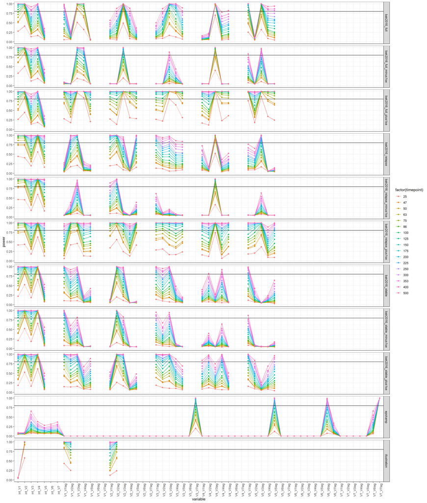

```r
p = df_res %>%
    gather(variable, power, starts_with("pow")) %>%
    mutate(variable = str_replace(variable, "pow_", "")) %>%
    ggplot(aes(y=power, x=variable, color=factor(timepoint), group=factor(timepoint))) +
        geom_line() +
        geom_point() +
        geom_hline(yintercept = .8) +
        facet_grid(name~.) +
        theme_bw() +
        theme(axis.text.x = element_text(angle = 90))

ggsave("figures/outputs/power_curve.png", plot=p)
p
```

# 6 PAA results

The following table displays the SPAP score for each model and each R² targeted.

```r
# Reshape dataframe to get a table
table_paa <- df_res %>%
    gather(paa, paa_score, starts_with("PAP")) %>%
    dplyr::select(c(dataset=name,variables=vars,timepoint,paa,paa_score)) %>%
    spread(timepoint, paa_score)

# Transform in kable and add a second header
T_number <- ncol(table_paa) - 2
rows_grey <- c(outer(seq(1, nrow(table_paa), by = 6), 0:2, "+"))
table_paa <- kbl(table_paa) %>%
  kable_classic() %>%
  add_header_above(c(" " = 2, "T" = T_number)) %>%
  # Add row line every 3 rows
  row_spec(rows_grey, background = "lightgray")

# Save kable
# save_kable(table_paa, "figures/outputs/table_paa.png")

table_paa
```

| dataset | variables | T paa | T 25 | T 47 | T 50 | T 63 | T 75 | T 86 | T 100 | T 125 | T 150 | T 175 | T 200 | T 225 | T 250 | T 300 | T 353 | T 400 | T 500 |
| --- | --- | --- | --- | --- | --- | --- | --- | --- | --- | --- | --- | --- | --- | --- | --- | --- | --- | --- | --- |
| bak2016_full | 5 | PAP_0.9 | 0.0000 | 0.0002 | 0.0004 | 0.0086 | 0.0334 | 0.0988 | 0.2406 | 0.5440 | 0.7900 | 0.9178 | 0.9814 | 0.9948 | 0.9984 | 0.9998 | 1.0000 | 1.0000 | 1.0000 |
| bak2016_full | 5 | PAP_0.92 | 0.0000 | 0.0002 | 0.0002 | 0.0006 | 0.0048 | 0.0208 | 0.0726 | 0.2404 | 0.4866 | 0.6944 | 0.8626 | 0.9466 | 0.9780 | 0.9986 | 0.9998 | 1.0000 | 1.0000 |
| bak2016_full | 5 | PAP_0.95 | 0.0000 | 0.0000 | 0.0000 | 0.0000 | 0.0000 | 0.0002 | 0.0020 | 0.0084 | 0.0464 | 0.1188 | 0.2580 | 0.4180 | 0.5498 | 0.8074 | 0.9432 | 0.9832 | 0.9994 |
| bak2016_full_minus1se | 5 | PAP_0.9 | 0.0000 | 0.0004 | 0.0014 | 0.0100 | 0.0426 | 0.1142 | 0.2620 | 0.5968 | 0.8254 | 0.9564 | 0.9874 | 0.9958 | 0.9996 | 1.0000 | 1.0000 | 1.0000 | 1.0000 |
| bak2016_full_minus1se | 5 | PAP_0.92 | 0.0000 | 0.0000 | 0.0000 | 0.0012 | 0.0078 | 0.0250 | 0.0768 | 0.2718 | 0.5088 | 0.7718 | 0.8926 | 0.9580 | 0.9886 | 0.9996 | 1.0000 | 1.0000 | 1.0000 |
| bak2016_full_minus1se | 5 | PAP_0.95 | 0.0000 | 0.0000 | 0.0000 | 0.0000 | 0.0000 | 0.0004 | 0.0018 | 0.0134 | 0.0448 | 0.1432 | 0.2568 | 0.4268 | 0.6024 | 0.8476 | 0.9534 | 0.9914 | 0.9994 |
| bak2016_full_plus1se | 5 | PAP_0.9 | 0.0000 | 0.0014 | 0.0020 | 0.0164 | 0.0512 | 0.1070 | 0.2090 | 0.4464 | 0.6982 | 0.8128 | 0.9088 | 0.9522 | 0.9756 | 0.9930 | 0.9970 | 0.9998 | 1.0000 |
| bak2016_full_plus1se | 5 | PAP_0.92 | 0.0000 | 0.0000 | 0.0002 | 0.0026 | 0.0108 | 0.0298 | 0.0672 | 0.2126 | 0.4624 | 0.6080 | 0.7774 | 0.8734 | 0.9224 | 0.9728 | 0.9928 | 0.9978 | 1.0000 |
| bak2016_full_plus1se | 5 | PAP_0.95 | 0.0000 | 0.0000 | 0.0000 | 0.0000 | 0.0004 | 0.0006 | 0.0024 | 0.0118 | 0.0590 | 0.1246 | 0.2408 | 0.3918 | 0.5204 | 0.7388 | 0.8816 | 0.9420 | 0.9908 |
| bak2016_relapse | 5 | PAP_0.9 | 0.0000 | 0.0008 | 0.0008 | 0.0120 | 0.0412 | 0.1082 | 0.2644 | 0.5582 | 0.8424 | 0.9400 | 0.9804 | 0.9964 | 0.9998 | 1.0000 | 1.0000 | 1.0000 | 1.0000 |
| bak2016_relapse | 5 | PAP_0.92 | 0.0000 | 0.0000 | 0.0002 | 0.0018 | 0.0068 | 0.0240 | 0.0818 | 0.2422 | 0.5264 | 0.7416 | 0.8804 | 0.9584 | 0.9874 | 0.9972 | 1.0000 | 1.0000 | 1.0000 |
| bak2016_relapse | 5 | PAP_0.95 | 0.0000 | 0.0000 | 0.0000 | 0.0000 | 0.0002 | 0.0006 | 0.0004 | 0.0110 | 0.0510 | 0.1314 | 0.2596 | 0.4362 | 0.5950 | 0.8150 | 0.9608 | 0.9836 | 0.9992 |
| bak2016_relapse_minus1se | 5 | PAP_0.9 | 0.0000 | 0.0004 | 0.0016 | 0.0100 | 0.0472 | 0.1056 | 0.2760 | 0.5942 | 0.8336 | 0.9520 | 0.9886 | 0.9988 | 0.9990 | 1.0000 | 1.0000 | 1.0000 | 1.0000 |
| bak2016_relapse_minus1se | 5 | PAP_0.92 | 0.0000 | 0.0000 | 0.0004 | 0.0014 | 0.0062 | 0.0236 | 0.0806 | 0.2614 | 0.5348 | 0.7644 | 0.9010 | 0.9652 | 0.9862 | 0.9994 | 1.0000 | 1.0000 | 1.0000 |
| bak2016_relapse_minus1se | 5 | PAP_0.95 | 0.0000 | 0.0000 | 0.0000 | 0.0000 | 0.0000 | 0.0004 | 0.0036 | 0.0124 | 0.0520 | 0.1386 | 0.2692 | 0.4578 | 0.5982 | 0.8400 | 0.9546 | 0.9870 | 0.9996 |
| bak2016_relapse_plus1se | 5 | PAP_0.9 | 0.0000 | 0.0002 | 0.0016 | 0.0144 | 0.0402 | 0.1110 | 0.2566 | 0.5656 | 0.8148 | 0.9314 | 0.9810 | 0.9944 | 0.9986 | 1.0000 | 1.0000 | 1.0000 | 1.0000 |
| bak2016_relapse_plus1se | 5 | PAP_0.92 | 0.0000 | 0.0000 | 0.0002 | 0.0012 | 0.0054 | 0.0268 | 0.0772 | 0.2518 | 0.5068 | 0.7346 | 0.8770 | 0.9490 | 0.9842 | 0.9990 | 1.0000 | 1.0000 | 1.0000 |
| bak2016_relapse_plus1se | 5 | PAP_0.95 | 0.0000 | 0.0000 | 0.0000 | 0.0000 | 0.0000 | 0.0004 | 0.0010 | 0.0128 | 0.0512 | 0.1372 | 0.2722 | 0.4302 | 0.5872 | 0.8246 | 0.9462 | 0.9830 | 0.9990 |
| bak2016_stable | 5 | PAP_0.9 | 0.0000 | 0.0002 | 0.0006 | 0.0082 | 0.0402 | 0.0942 | 0.2242 | 0.5160 | 0.8072 | 0.9306 | 0.9816 | 0.9970 | 0.9996 | 1.0000 | 1.0000 | 1.0000 | 1.0000 |
| bak2016_stable | 5 | PAP_0.92 | 0.0000 | 0.0002 | 0.0000 | 0.0012 | 0.0086 | 0.0232 | 0.0630 | 0.2234 | 0.4896 | 0.7194 | 0.8792 | 0.9558 | 0.9820 | 0.9986 | 0.9996 | 1.0000 | 1.0000 |
| bak2016_stable | 5 | PAP_0.95 | 0.0000 | 0.0000 | 0.0000 | 0.0000 | 0.0000 | 0.0000 | 0.0016 | 0.0090 | 0.0462 | 0.1268 | 0.2592 | 0.4082 | 0.5608 | 0.8118 | 0.9480 | 0.9830 | 0.9988 |
| bak2016_stable_minus1se | 5 | PAP_0.9 | 0.0000 | 0.0002 | 0.0010 | 0.0090 | 0.0376 | 0.1048 | 0.2224 | 0.5808 | 0.8042 | 0.9394 | 0.9840 | 0.9956 | 0.9990 | 1.0000 | 1.0000 | 1.0000 | 1.0000 |
| bak2016_stable_minus1se | 5 | PAP_0.92 | 0.0000 | 0.0000 | 0.0000 | 0.0014 | 0.0078 | 0.0206 | 0.0616 | 0.2584 | 0.4930 | 0.7348 | 0.8916 | 0.9556 | 0.9850 | 0.9984 | 0.9998 | 1.0000 | 1.0000 |
| bak2016_stable_minus1se | 5 | PAP_0.95 | 0.0000 | 0.0000 | 0.0000 | 0.0000 | 0.0000 | 0.0000 | 0.0010 | 0.0130 | 0.0490 | 0.1274 | 0.2582 | 0.4198 | 0.5782 | 0.8032 | 0.9410 | 0.9834 | 0.9990 |
| bak2016_stable_plus1se | 5 | PAP_0.9 | 0.0000 | 0.0000 | 0.0002 | 0.0070 | 0.0314 | 0.0872 | 0.2012 | 0.4854 | 0.7574 | 0.9126 | 0.9712 | 0.9938 | 0.9984 | 1.0000 | 1.0000 | 1.0000 | 1.0000 |
| bak2016_stable_plus1se | 5 | PAP_0.92 | 0.0000 | 0.0000 | 0.0000 | 0.0012 | 0.0054 | 0.0182 | 0.0542 | 0.2042 | 0.4624 | 0.7006 | 0.8502 | 0.9372 | 0.9760 | 0.9970 | 0.9992 | 0.9998 | 1.0000 |
| bak2016_stable_plus1se | 5 | PAP_0.95 | 0.0000 | 0.0000 | 0.0000 | 0.0000 | 0.0000 | 0.0002 | 0.0006 | 0.0066 | 0.0412 | 0.1178 | 0.2302 | 0.3810 | 0.5464 | 0.7930 | 0.9392 | 0.9810 | 0.9992 |
| epskamp | 7 | PAP_0.9 | 0.0780 | 0.4204 | 0.4678 | 0.6418 | 0.7420 | 0.8112 | 0.8764 | 0.9446 | 0.9720 | 0.9850 | 0.9906 | 0.9954 | 0.9972 | 0.9996 | 1.0000 | 0.9998 | 1.0000 |
| epskamp | 7 | PAP_0.92 | 0.0366 | 0.2638 | 0.2968 | 0.4596 | 0.5670 | 0.6570 | 0.7596 | 0.8612 | 0.9130 | 0.9498 | 0.9616 | 0.9836 | 0.9848 | 0.9944 | 0.9994 | 0.9992 | 0.9998 |
| epskamp | 7 | PAP_0.95 | 0.0052 | 0.0678 | 0.0734 | 0.1442 | 0.2116 | 0.2968 | 0.3932 | 0.5448 | 0.6390 | 0.7158 | 0.7840 | 0.8294 | 0.8636 | 0.9112 | 0.9404 | 0.9588 | 0.9784 |
| illustration | 2 | PAP_0.9 | 0.0774 | 0.3422 | 0.3930 | 0.5290 | 0.6456 | 0.7302 | 0.8286 | 0.9038 | 0.9610 | 0.9790 | 0.9930 | 0.9956 | 0.9978 | 0.9996 | 0.9998 | 1.0000 | 1.0000 |
| illustration | 2 | PAP_0.92 | 0.0450 | 0.2384 | 0.2800 | 0.3968 | 0.5026 | 0.6052 | 0.7130 | 0.8226 | 0.9122 | 0.9476 | 0.9768 | 0.9860 | 0.9916 | 0.9982 | 0.9994 | 1.0000 | 1.0000 |
| illustration | 2 | PAP_0.95 | 0.0116 | 0.0886 | 0.1066 | 0.1718 | 0.2410 | 0.3222 | 0.4228 | 0.5582 | 0.6910 | 0.7752 | 0.8616 | 0.8924 | 0.9354 | 0.9696 | 0.9856 | 0.9944 | 0.9992 |

The following plot displays the SPAP score for each model (colors) and each R² targeted (panels).

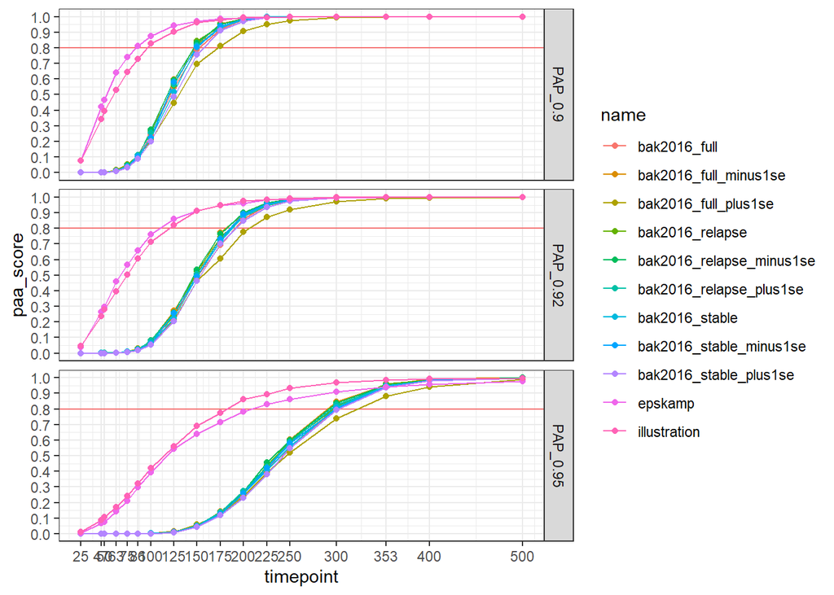

```r
breaks = unique(df_res$timepoint)

p = df_res %>%
    gather(paa, paa_score, starts_with("PAP")) %>%
    dplyr::select(c(name,vars,timepoint,paa,paa_score)) %>%
    ggplot(aes(y=paa_score, x= timepoint, color=name)) +
        geom_hline(yintercept = .8, color="red", alpha=.5) +
        geom_line() +
        geom_point() +
        scale_x_continuous(breaks = breaks) +
        scale_y_continuous(breaks = seq(0,1,.1)) +
        theme_bw() +
        facet_grid(paa~.)

ggsave("figures/outputs/paa_curve.png", plot=p)
p
```